# TCC_scraping_abt_parte2

## Modelo preditivo para classificação de posts no Intagram do mercado de papelarias

## Criando dataframe a partir de API do Instagram

### Importando libraries

```python
from os import system
import time
import pandas as pd
import numpy as np
from datetime import datetime as dt
from datetime import datetime, timedelta
from selenium.common.exceptions import NoSuchElementException
import matplotlib.pyplot as plt
import seaborn as sns
import os
import wget
```

```python
# !pip install igramscraper
```

### Código para scraping do Instagram

```python
from igramscraper.instagram import Instagram
import datetime as dt
import time
import pandas as pd
import numpy as np
from tqdm import notebook

account_names = pd.read_csv('shops.csv').iloc[:,0].tolist()

# Instantiating the scrapper class
instagram = Instagram()

# list to store data
data = []

# Iterating each account name
ix_strt = 0
for account_name in notebook.tqdm(account_names[ix_strt:]):
    time.sleep(120)
    # Get account
    account = instagram.get_account(account_name)
    # Retrieve identifier
    identifier = account.identifier
    # Get vector of medias
    medias = instagram.get_medias_by_user_id(id=identifier, count=30) # número de posts por perfil
    # Iterating for each media
    for media in medias:
        try:
            # Storing data
            data.append([
                account_name,
                account.full_name,
                account.biography,
                account.is_business_account,
                account.is_joined_recently,
                account.is_verified,
                account.business_category_name,
                account.business_email,
                account.business_phone_number,
                account.connected_fb_page,
                account.followed_by_count,
                account.follows_count,
                account.has_channel,
                account.media_count,
                media.caption,
                dt.datetime.fromtimestamp(media.created_time),
                media.comments_count,
                media.comments_next_page,
                media.has_more_comments,
                media.image_high_resolution_url,
                media.is_ad,
                media.likes_count,
                media.link,
                media.location_name,
                media.video_views,
                media.type,
            ])
            time.sleep(30)
        except Exception as e:
            print(f"accountID:{account.identifier} mediaID:{media.identifier} Error:{e}")
            pass
```

```python
# Definindo as colunas da base e salvando em xlsx

cols = [
    'account_name',
    'full_name',
    'biography',
    'is_business_account',
    'is_joined_recently',
    'is_verified',
    'business_category_name',
    'business_email',
    'business_phone_number',
    'connected_fb_page',
    'followed_by_count',
    'follows_count',
    'has_channel',
    'media_count',
    'caption',
    'created_time',
    'comments_count',
    'comments_next_page',
    'has_more_comments',
    'image_high_resolution_url',
    'is_ad',
    'likes_count',
    'link',
    'location_name',
    'video_views',
    'type'
]

pd.DataFrame(data,columns=cols).to_excel('sample_data.xlsx',index=False)
```

### Estruturando dataframe

```python
# # Analisando os df's gerados
df = pd.read_excel('sample_data_abt.xlsx')
df.head(1)
```

|  | account_name | full_name | biography | is_business_account | is_joined_recently | is_verified | business_category_name | business_email | business_phone_number | connected_fb_page | ... | comments_count | comments_next_page | has_more_comments | image_high_resolution_url | is_ad | likes_count | link | location_name | video_views | type |
| --- | --- | --- | --- | --- | --- | --- | --- | --- | --- | --- | --- | --- | --- | --- | --- | --- | --- | --- | --- | --- | --- |
| 0 | papelarialiane | Papelaria Liane | 📍Rua Paulo Eduardo Xavier de Toledo; 419, Itú/... | False | False | False | NaN | NaN | NaN | NaN | ... | 2 | NaN | False | https://instagram.fbhz6-1.fna.fbcdn.net/v/t51.... | False | 43 | https://www.instagram.com/p/CShD4lTLE2C | NaN | 0 | image |

1 rows × 26 columns

```python
df.shape
```

```
(2835, 26)
```

```python
df.columns
```

```
Index(['account_name', 'full_name', 'biography', 'is_business_account',
       'is_joined_recently', 'is_verified', 'business_category_name',
       'business_email', 'business_phone_number', 'connected_fb_page',
       'followed_by_count', 'follows_count', 'has_channel', 'media_count',
       'caption', 'created_time', 'comments_count', 'comments_next_page',
       'has_more_comments', 'image_high_resolution_url', 'is_ad',
       'likes_count', 'link', 'location_name', 'video_views', 'type'],
      dtype='object')
```

```python
df.info()
```

```
<class 'pandas.core.frame.DataFrame'>
RangeIndex: 2835 entries, 0 to 2834
Data columns (total 26 columns):
 #   Column                     Non-Null Count  Dtype
---  ------                     --------------  -----
 0   account_name               2835 non-null   object
 1   full_name                  2795 non-null   object
 2   biography                  2835 non-null   object
 3   is_business_account        2835 non-null   bool
 4   is_joined_recently         2835 non-null   bool
 5   is_verified                2835 non-null   bool
 6   business_category_name     2293 non-null   object
 7   business_email             0 non-null      float64
 8   business_phone_number      0 non-null      float64
 9   connected_fb_page          0 non-null      float64
```

[output cut: 18 more lines]

```python
# Criando a abt de posts
df_posts = pd.DataFrame()
```

```python
# Checar tamanho da base
df_posts = df_posts.append(df, ignore_index = True)
df_posts.shape
```

```
(2835, 26)
```

```python
# salvar base consolidada
#pd.DataFrame(df_posts).to_excel('sample_data_abt.xlsx',index=False)
```

```python
# total de shops da base
shops = df_posts['account_name'].nunique()

print('-----------')
print(f'Total de {shops} papelarias sendo analisadas no dataframe')
```

```
-----------
Total de 99 papelarias sendo analisadas no dataframe
```

#### Avaliando a quantidade de posts por shop

```python
qtd_posts = df_posts.groupby(by='account_name')[['link']].count()

qtd_posts.head(3)
```

| account_name | link |
| --- | --- |
| a.papelariacriativa | 25 |
| amomywish | 25 |
| artpelpapelaria | 25 |

- Todos os Shops apresentam links de posts

```python
qtd_posts[qtd_posts['link'] == 0]
```

|  | link |
| --- | --- |
| account_name |  |

```python
qtd_posts['link'].mean()
```

```
28.636363636363637
```

```python
qtd_posts['link'].describe()
```

```
count    99.000000
mean     28.636364
std       7.167749
min      12.000000
25%      25.000000
50%      25.000000
75%      30.000000
max      40.000000
Name: link, dtype: float64
```

- A média de posts por shop é em torno de 28 e a mediana 25.
- O mínimo de posts coletados de uma papelaria foi 12 e o máximo 40.

```python
df_posts.isnull().sum()
```

```
account_name                    0
full_name                      40
biography                       0
is_business_account             0
is_joined_recently              0
is_verified                     0
business_category_name        542
business_email               2835
business_phone_number        2835
connected_fb_page            2835
followed_by_count               0
follows_count                   0
has_channel                     0
media_count                     0
caption                        45
created_time                    0
comments_count                  0
comments_next_page           2835
has_more_comments               0
image_high_resolution_url       0
is_ad                           0
likes_count                     0
link                            0
location_name                2835
video_views                     0
type                            0
dtype: int64
```

#### Análise dos perfis dos shops

- Perfis bem diversos, como é possível observar, levando em consideração o desvio padrão

```python
n_shops = df_posts[['account_name', 'is_business_account', 'followed_by_count', 'follows_count','media_count']].drop_duplicates()

n_shops.describe()
```

|  | followed_by_count | follows_count | media_count |
| --- | --- | --- | --- |
| count | 99.000000 | 99.000000 | 99.000000 |
| mean | 30618.212121 | 1243.040404 | 625.363636 |
| std | 61918.342674 | 1722.172927 | 1118.084664 |
| min | 78.000000 | 1.000000 | 12.000000 |
| 25% | 625.000000 | 133.000000 | 108.500000 |
| 50% | 5093.000000 | 491.000000 | 299.000000 |
| 75% | 27445.500000 | 1517.000000 | 672.500000 |
| max | 364602.000000 | 7500.000000 | 9547.000000 |

```python
df_posts['is_business_account'].value_counts(1)
```

```
True     0.808818
False    0.191182
Name: is_business_account, dtype: float64
```

```python
# Feature também pode ser removida
df_posts['is_joined_recently'].value_counts(1)
```

```
False    1.0
Name: is_joined_recently, dtype: float64
```

```python
#posts_abt.pivot_table(index = ['followed_by_count']), aggfunc ='size')

pd.pivot_table(df_posts,
               index = ["full_name"],
               values = ["followed_by_count",'follows_count'])
```

| full_name | followed_by_count | follows_count |
| --- | --- | --- |
| Aruna Papelaria | 1429.0 | 637.0 |
| Avante Papelaria | 34483.0 | 3736.0 |
| Barquinho de Papel | 139.0 | 43.0 |
| Bendita Seja | 60633.0 | 3795.0 |
| Bisou Papier® - papelaria fina | 45709.0 | 1240.0 |
| ... | ... | ... |
| ¡Me encanta que te encante!® | 16783.0 | 2914.0 |
| ♥ Planners e papelaria ♥ | 50916.0 | 111.0 |
| ✨De Papier \| Papelaria Fofa✨ | 71133.0 | 5328.0 |
| 💕🌸Papelaria Fofa em BH 🌸🎀 | 155.0 | 122.0 |
| 📚 Papelaria Betim 📚 | 2807.0 | 1610.0 |

97 rows × 2 columns

### Cálculo do engajamento

```python
# Criando coluna de engajamento

df_posts['eng_rate'] = 0
```

```python
# Calculando taxa de engajamento na base

for index, row in df_posts.iterrows():
    rate = ((df_posts.iloc[index]['likes_count'] / df_posts.iloc[index]['followed_by_count']))


    df_posts.loc[index, 'eng_rate'] = rate
```

```python
df_posts.head()
```

|  | account_name | full_name | biography | is_business_account | is_joined_recently | is_verified | business_category_name | business_email | business_phone_number | connected_fb_page | ... | comments_next_page | has_more_comments | image_high_resolution_url | is_ad | likes_count | link | location_name | video_views | type | eng_rate |
| --- | --- | --- | --- | --- | --- | --- | --- | --- | --- | --- | --- | --- | --- | --- | --- | --- | --- | --- | --- | --- | --- |
| 0 | papelarialiane | Papelaria Liane | 📍Rua Paulo Eduardo Xavier de Toledo; 419, Itú/... | False | False | False | NaN | NaN | NaN | NaN | ... | NaN | False | https://instagram.fbhz6-1.fna.fbcdn.net/v/t51.... | False | 43 | https://www.instagram.com/p/CShD4lTLE2C | NaN | 0 | image | 0.000716 |
| 1 | papelarialiane | Papelaria Liane | 📍Rua Paulo Eduardo Xavier de Toledo; 419, Itú/... | False | False | False | NaN | NaN | NaN | NaN | ... | NaN | False | https://instagram.fbhz6-1.fna.fbcdn.net/v/t51.... | False | 70 | https://www.instagram.com/p/CSgsvz_rV1B | NaN | 0 | image | 0.001166 |
| 2 | papelarialiane | Papelaria Liane | 📍Rua Paulo Eduardo Xavier de Toledo; 419, Itú/... | False | False | False | NaN | NaN | NaN | NaN | ... | NaN | False | https://instagram.fbhz6-1.fna.fbcdn.net/v/t51.... | False | 15 | https://www.instagram.com/p/CSfjFF1H7zV | NaN | 0 | video | 0.000250 |
| 3 | papelarialiane | Papelaria Liane | 📍Rua Paulo Eduardo Xavier de Toledo; 419, Itú/... | False | False | False | NaN | NaN | NaN | NaN | ... | NaN | False | https://instagram.fbhz6-1.fna.fbcdn.net/v/t51.... | False | 54 | https://www.instagram.com/p/CSfP3jtrbLQ | NaN | 0 | sidecar | 0.000900 |
| 4 | papelarialiane | Papelaria Liane | 📍Rua Paulo Eduardo Xavier de Toledo; 419, Itú/... | False | False | False | NaN | NaN | NaN | NaN | ... | NaN | False | https://instagram.fbhz6-1.fna.fbcdn.net/v/t51.... | False | 24 | https://www.instagram.com/p/CScyNG7H_FX | NaN | 0 | video | 0.000400 |

5 rows × 27 columns

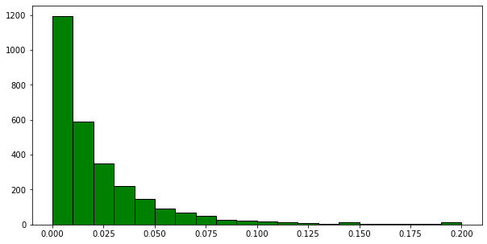

```python
# Histograma de rates

import matplotlib.pyplot as plt

fig, ax = plt.subplots(figsize=(10,5))

df_posts['eng_rate'].clip(upper=0.2).hist(bins=20,grid = False,color='green',ec='k')
```

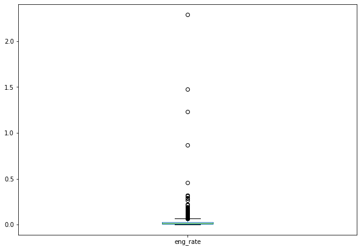

```python
# Box-plot: presença de outliers
fig, ax = plt.subplots(figsize=(10,7))
df_posts.boxplot(column='eng_rate',grid=False, ax=ax)
```

- Boxplot pode indicar presença de outliers.
- Engajamento superior a 1 representa que o post teve mais curtidas do que o número total de seguidores daquele perfil.
- Importante sinalizar aqui que taxas superiores a 1 podem indicar algum comportamente ilegal como compra de likes, etc.

### Análise de outliers

```python
# # Análise de outliers baseada no intervalo interquartil - NÃO UTILIZADO

# # Cálculo do intervalo interquartil
# Q1 = df_posts['eng_rate'].quantile(0.25)
# Q3 = df_posts['eng_rate'].quantile(0.75)
# IQR = Q3 - Q1
# print(IQR)

# # Valor do quartil P9
# df_posts['eng_rate'].quantile(0.95)

# # Cálculos dos limites inferior e superior

# LS = Q3 + 1.5 * IQR
# LI = Q1 - 1.5 * IQR

# print(LS, LI)
```

- Iremos adotar aqui a premissa de negócio de trabalharemos apenas com posts de até 100% de engajamento.

```python
# Verificando quantos posts estão acima da premissa de negócio

df_posts[df_posts['eng_rate'] > 1]['account_name'].count()
```

```
3
```

```python
# Removendo outliers da base: base passa a ter 3 posts a menos

df_posts_sem_out = df_posts.query('eng_rate <= 1')
df_posts_sem_out.shape
```

```
(2832, 27)
```

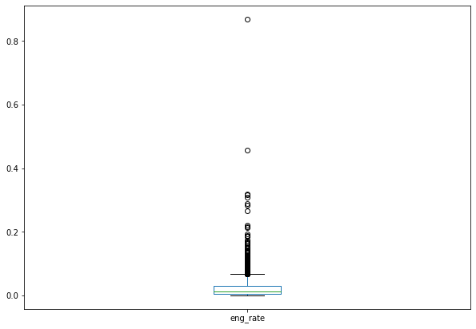

```python
# Novo Box-plot sem outliers
fig, ax = plt.subplots(figsize=(10,7))
df_posts_sem_out.boxplot(column='eng_rate',grid=False, ax=ax)
```

```python
df_posts_sem_out['eng_rate'].describe()
```

```
count    2832.000000
mean        0.023179
std         0.034646
min         0.000000
25%         0.004341
50%         0.013083
75%         0.029601
max         0.868234
Name: eng_rate, dtype: float64
```

```python
df_posts_sem_out.query('eng_rate == 0.0000')['account_name'].count()
```

```
2
```

```python
# Análise dos outliers

# df_posts_out = df_posts.query('eng_rate > 0.06773772418956658')
# df_posts_out.shape
```

```python
# Avaliando posts outliers

# df_posts_out.sort_values(by='eng_rate', ascending=False)
```

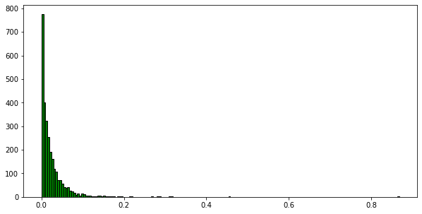

```python
# Histograma sem outliers

fig, ax = plt.subplots(figsize=(10,5))
df_posts_sem_out['eng_rate'].hist(bins=180,grid = False,color='green',ec='k')
```

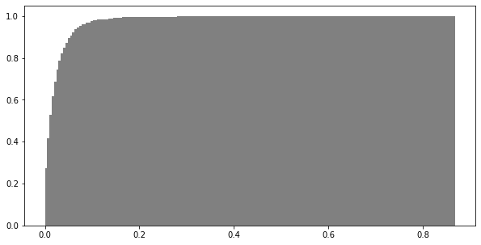

```python
# Histograma sem outliers

fig, ax = plt.subplots(figsize=(10,5))
df_posts_sem_out['eng_rate'].hist(bins=180,grid = False,color='grey', density=True, cumulative=True)
```

## Definição do target

### Regra de negócio

- Engajamento do post definido pela taxa média do setor de 'shopping and retail': 2,8%
- Artigo referência: https://www.affde.com/pt/average-instagram-engagement-rate.html

```python
# Definindo qual base será utilizada (neste caso, sem outliers)
# nova variável base: posts_abt

posts_abt = df_posts_sem_out
```

```python
posts_abt.shape
```

```
(2832, 27)
```

```python
# Confirmação de que a maior parte dos shops estão categorizados como shopping and retail

posts_abt.groupby('business_category_name').size()
```

```
business_category_name
Business & Utility Services                      25
Creators & Celebrities                          751
Food & Personal Goods                            80
General Interest                                 30
Home Services                                    25
Lifestyle Services                               25
Personal Goods & General Merchandise Stores    1354
dtype: int64
```

```python
posts_abt['business_category_name'].value_counts(1)
```

```
Personal Goods & General Merchandise Stores    0.591266
Creators & Celebrities                         0.327948
Food & Personal Goods                          0.034934
General Interest                               0.013100
Business & Utility Services                    0.010917
Lifestyle Services                             0.010917
Home Services                                  0.010917
Name: business_category_name, dtype: float64
```

- Apesar de todos os perfis serem voltados para venda de produtos, alguns se classificam como criadores de conteúdo.
- Vamos ver no modelo se isso pode influenciar no engajamento.

```python
posts_abt['eng_rate'].describe()
```

```
count    2832.000000
mean        0.023179
std         0.034646
min         0.000000
25%         0.004341
50%         0.013083
75%         0.029601
max         0.868234
Name: eng_rate, dtype: float64
```

```python
# Esse valor é aproximadamente o P75 da base

posts_abt[posts_abt['eng_rate'] >= 0.028]['eng_rate'].count()
```

```
752
```

```python
corte = 0.028
corte
```

```
0.028
```

```python
# Criando coluna do target no novo dataframe sem outlier
posts_abt['target'] = 0
```

```python
# Aplicando target

posts_abt['target'] = posts_abt['eng_rate'].apply(lambda x: 1 if x > corte else 0)
posts_abt.head(1)
```

|  | account_name | full_name | biography | is_business_account | is_joined_recently | is_verified | business_category_name | business_email | business_phone_number | connected_fb_page | ... | has_more_comments | image_high_resolution_url | is_ad | likes_count | link | location_name | video_views | type | eng_rate | target |
| --- | --- | --- | --- | --- | --- | --- | --- | --- | --- | --- | --- | --- | --- | --- | --- | --- | --- | --- | --- | --- | --- |
| 0 | papelarialiane | Papelaria Liane | 📍Rua Paulo Eduardo Xavier de Toledo; 419, Itú/... | False | False | False | NaN | NaN | NaN | NaN | ... | False | https://instagram.fbhz6-1.fna.fbcdn.net/v/t51.... | False | 43 | https://www.instagram.com/p/CShD4lTLE2C | NaN | 0 | image | 0.000716 | 0 |

1 rows × 28 columns

```python
posts_abt.shape
```

```
(2832, 28)
```

```python
posts_abt['target'].value_counts(1)
```

```
0    0.734463
1    0.265537
Name: target, dtype: float64
```

Nesta base temos que 26,5% dos posts geraram engajamento

```python
aux_target = posts_abt.groupby('target')[['account_name']].count().reset_index()
aux_target
```

|  | target | account_name |
| --- | --- | --- |
| 0 | 0 | 2080 |
| 1 | 1 | 752 |

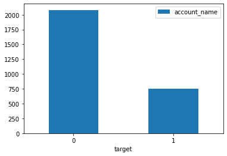

```python
ax = aux_target.plot.bar(x='target', rot=0)
```

## Ajuste de features

```python
# Base original

posts_abt.columns
```

```
Index(['account_name', 'full_name', 'biography', 'is_business_account',
       'is_joined_recently', 'is_verified', 'business_category_name',
       'business_email', 'business_phone_number', 'connected_fb_page',
       'followed_by_count', 'follows_count', 'has_channel', 'media_count',
       'caption', 'created_time', 'comments_count', 'comments_next_page',
       'has_more_comments', 'image_high_resolution_url', 'is_ad',
       'likes_count', 'link', 'location_name', 'video_views', 'type',
       'eng_rate', 'target'],
      dtype='object')
```

```python
# Removendo features que não serão utilizadas

posts_abt = posts_abt[['link',
                       'account_name',
                       'is_business_account',
                       'business_category_name',
                       'followed_by_count', # será removida para modelo
                       'follows_count',
                       'media_count',
                       'comments_count',
                       'caption',
                       'created_time',
                       'likes_count', # será removida para modelo
                       'type',
                       'eng_rate',
                       'target']]
```

```python
posts_abt
```

|  | link | account_name | is_business_account | business_category_name | followed_by_count | follows_count | media_count | comments_count | caption | created_time | likes_count | type | eng_rate | target |
| --- | --- | --- | --- | --- | --- | --- | --- | --- | --- | --- | --- | --- | --- | --- |
| 0 | https://www.instagram.com/p/CShD4lTLE2C | papelarialiane | False | NaN | 60016 | 617 | 2977 | 2 | Ei, fique atento! Coisas boas acontecem todos ... | 2021-08-13 10:39:26 | 43 | image | 0.000716 | 0 |
| 1 | https://www.instagram.com/p/CSgsvz_rV1B | papelarialiane | False | NaN | 60016 | 617 | 2977 | 3 | Essa combinação da caneta e caderno?! 💓 \nCont... | 2021-08-13 07:17:16 | 70 | image | 0.001166 | 0 |
| 2 | https://www.instagram.com/p/CSfjFF1H7zV | papelarialiane | False | NaN | 60016 | 617 | 2977 | 7 | Caneta que escreve com contorno.\n.\nNosso sit... | 2021-08-12 20:36:24 | 15 | video | 0.000250 | 0 |
| 3 | https://www.instagram.com/p/CSfP3jtrbLQ | papelarialiane | False | NaN | 60016 | 617 | 2977 | 4 | Essas canetas conquistaram nossos corações.\n.... | 2021-08-12 17:45:41 | 54 | sidecar | 0.000900 | 0 |
| 4 | https://www.instagram.com/p/CScyNG7H_FX | papelarialiane | False | NaN | 60016 | 617 | 2977 | 10 | Para os apaixonados por Lettering e desenhos q... | 2021-08-11 18:48:14 | 24 | video | 0.000400 | 0 |
| ... | ... | ... | ... | ... | ... | ... | ... | ... | ... | ... | ... | ... | ... | ... |
| 2830 | https://www.instagram.com/p/CR4DWFVsvZX | magpapelaria | True | Personal Goods & General Merchandise Stores | 58497 | 2280 | 1431 | 0 | Corre pra aproveitar a promoção da coleção mai... | 2021-07-28 12:25:52 | 89 | sidecar | 0.001521 | 0 |
| 2831 | https://www.instagram.com/p/CR2SBF8Hjg9 | magpapelaria | True | Personal Goods & General Merchandise Stores | 58497 | 2280 | 1431 | 7 | Estamos apaixonadas pelas canetas Pentel Energ... | 2021-07-27 19:56:41 | 259 | video | 0.004428 | 0 |
| 2832 | https://www.instagram.com/p/CR2BXWVpnA8 | magpapelaria | True | Personal Goods & General Merchandise Stores | 58497 | 2280 | 1431 | 2 | Pra deixar sua rotina mais divertida! 😍\n⠀⠀⠀⠀⠀... | 2021-07-27 17:30:08 | 120 | image | 0.002051 | 0 |
| 2833 | https://www.instagram.com/p/CRztyGwtAkV | magpapelaria | True | Personal Goods & General Merchandise Stores | 58497 | 2280 | 1431 | 12 | Desafio de volta às aulas! 📚\n⠀⠀⠀⠀⠀⠀⠀⠀⠀\nComen... | 2021-07-26 20:00:30 | 148 | sidecar | 0.002530 | 0 |
| 2834 | https://www.instagram.com/p/CRzgldWD1L_ | magpapelaria | True | Personal Goods & General Merchandise Stores | 58497 | 2280 | 1431 | 6 | Quais metas você quer realizar até o fim desse... | 2021-07-26 18:05:15 | 99 | image | 0.001692 | 0 |

2832 rows × 14 columns

```python
posts_abt.info()
```

```
<class 'pandas.core.frame.DataFrame'>
Int64Index: 2832 entries, 0 to 2834
Data columns (total 14 columns):
 #   Column                  Non-Null Count  Dtype
---  ------                  --------------  -----
 0   link                    2832 non-null   object
 1   account_name            2832 non-null   object
 2   is_business_account     2832 non-null   bool
 3   business_category_name  2290 non-null   object
 4   followed_by_count       2832 non-null   int64
 5   follows_count           2832 non-null   int64
 6   media_count             2832 non-null   int64
 7   comments_count          2832 non-null   int64
 8   caption                 2787 non-null   object
 9   created_time            2832 non-null   datetime64[ns]
 10  likes_count             2832 non-null   int64
 11  type                    2832 non-null   object
 12  eng_rate                2832 non-null   float64
 13  target                  2832 non-null   int64
dtypes: bool(1), datetime64[ns](1), float64(1), int64(6), object(5)
memory usage: 312.5+ KB
```

```python
# check campos vazios
posts_abt.isna().sum()
```

```
link                        0
account_name                0
is_business_account         0
business_category_name    542
followed_by_count           0
follows_count               0
media_count                 0
comments_count              0
caption                    45
created_time                0
likes_count                 0
type                        0
eng_rate                    0
target                      0
dtype: int64
```

```python
posts_abt['business_category_name'] = posts_abt['business_category_name'].fillna('not defined')
```

```python
posts_abt.info()
```

```
<class 'pandas.core.frame.DataFrame'>
Int64Index: 2832 entries, 0 to 2834
Data columns (total 14 columns):
 #   Column                  Non-Null Count  Dtype
---  ------                  --------------  -----
 0   link                    2832 non-null   object
 1   account_name            2832 non-null   object
 2   is_business_account     2832 non-null   bool
 3   business_category_name  2832 non-null   object
 4   followed_by_count       2832 non-null   int64
 5   follows_count           2832 non-null   int64
 6   media_count             2832 non-null   int64
 7   comments_count          2832 non-null   int64
 8   caption                 2787 non-null   object
 9   created_time            2832 non-null   datetime64[ns]
 10  likes_count             2832 non-null   int64
 11  type                    2832 non-null   object
 12  eng_rate                2832 non-null   float64
 13  target                  2832 non-null   int64
dtypes: bool(1), datetime64[ns](1), float64(1), int64(6), object(5)
memory usage: 312.5+ KB
```

```python
# Check posts duplicados

duplicate = posts_abt.duplicated()
print(duplicate.sum())
posts_abt[duplicate]
```

```
0
```

|  | link | account_name | is_business_account | business_category_name | followed_by_count | follows_count | media_count | comments_count | caption | created_time | likes_count | type | eng_rate | target |
| --- | --- | --- | --- | --- | --- | --- | --- | --- | --- | --- | --- | --- | --- | --- |

```python
# Remover duplicados, caso necessário

# posts_abt.drop_duplicates(inplace=True)
```

```python
# Novo check duplicadas

dup = posts_abt.duplicated()
dup.sum()
```

```
0
```

```python
# Convertendo UTC -> local_hour (-3h) para facilitar a análise com horário brasileiro

from datetime import datetime, timedelta

posts_abt['local_time'] = posts_abt['created_time'] - timedelta(hours=3)
```

```python
# Função para arredondar as horas do post

def rounder(t):
    if t.minute >= 30:
        return t.replace(second=0, microsecond=0, minute=0, hour=t.hour+1)
    else:
        return t.replace(second=0, microsecond=0, minute=0)
```

```python
# Criando coluna para inserir as horas arredondadas

posts_abt['r_local_time'] = posts_abt['local_time'].apply(rounder)
```

```python
# Criando coluna dia da semana (0-seg, 6-dom)
posts_abt['weekday'] = posts_abt['r_local_time'].dt.weekday
```

```python
# Catergorizando weekday

posts_abt["weekday"] = posts_abt["weekday"].replace({0:"mon",
                                                     1:"tue",
                                                     2:"wed",
                                                     3:"thu",
                                                     4:"fri",
                                                     5:"sat",
                                                     6:"sun"})

posts_abt.head(1)
```

|  | link | account_name | is_business_account | business_category_name | followed_by_count | follows_count | media_count | comments_count | caption | created_time | likes_count | type | eng_rate | target | local_time | r_local_time | weekday |
| --- | --- | --- | --- | --- | --- | --- | --- | --- | --- | --- | --- | --- | --- | --- | --- | --- | --- |
| 0 | https://www.instagram.com/p/CShD4lTLE2C | papelarialiane | False | not defined | 60016 | 617 | 2977 | 2 | Ei, fique atento! Coisas boas acontecem todos ... | 2021-08-13 10:39:26 | 43 | image | 0.000716 | 0 | 2021-08-13 07:39:26 | 2021-08-13 08:00:00 | fri |

```python
# Criando coluna hora da postagem
posts_abt['hour'] = posts_abt['r_local_time'].dt.hour
```

```python
# Criando coluna time ranges

posts_abt['time_range'] = 0
```

```python
# Classificando de acordo com time ranges
posts_abt.loc[(posts_abt['hour'] < 6), 'time_range'] = 'madrugada'
posts_abt.loc[(posts_abt['hour'] >= 6) & (posts_abt['hour'] < 12) , 'time_range'] = 'manha'
posts_abt.loc[(posts_abt['hour'] >= 12) & (posts_abt['hour'] < 18) , 'time_range'] = 'tarde'
posts_abt.loc[(posts_abt['hour'] >= 18) & (posts_abt['hour'] < 24) , 'time_range'] = 'noite'
```

```python
# Criando colunas para contar caracteres da descrição do post
posts_abt['caption_count'] = 0
posts_abt['caption_tag'] = 0
posts_abt['caption_hash'] = 0
```

```python
# Contando caracteres da descrição do post

posts_abt['caption_count'] = posts_abt["caption"].str.count("")
posts_abt['caption_tag'] = posts_abt["caption"].str.count("@")
posts_abt['caption_hash'] = posts_abt["caption"].str.count("#")
```

```python
# Tratando valores NA agora

#Check NA
#posts_abt_sem_out_model.isna().sum()

posts_abt['caption_count'] = posts_abt["caption_count"].fillna(0)
posts_abt['caption_tag'] = posts_abt["caption_tag"].fillna(0)
posts_abt['caption_hash'] = posts_abt["caption_hash"].fillna(0)
```

```python
# Convertendo novas colunas de contagem de caracteres em int

posts_abt['caption_count'] = posts_abt["caption_count"].astype(int)
posts_abt['caption_tag'] = posts_abt["caption_tag"].astype(int)
posts_abt['caption_hash'] = posts_abt["caption_hash"].astype(int)
```

```python
posts_abt.shape
```

```
(2832, 22)
```

```python
posts_abt.head(1)
```

|  | link | account_name | is_business_account | business_category_name | followed_by_count | follows_count | media_count | comments_count | caption | created_time | ... | eng_rate | target | local_time | r_local_time | weekday | hour | time_range | caption_count | caption_tag | caption_hash |
| --- | --- | --- | --- | --- | --- | --- | --- | --- | --- | --- | --- | --- | --- | --- | --- | --- | --- | --- | --- | --- | --- |
| 0 | https://www.instagram.com/p/CShD4lTLE2C | papelarialiane | False | not defined | 60016 | 617 | 2977 | 2 | Ei, fique atento! Coisas boas acontecem todos ... | 2021-08-13 10:39:26 | ... | 0.000716 | 0 | 2021-08-13 07:39:26 | 2021-08-13 08:00:00 | fri | 8 | manha | 91 | 0 | 0 |

1 rows × 22 columns

```python
posts_abt.info()
```

```
<class 'pandas.core.frame.DataFrame'>
Int64Index: 2832 entries, 0 to 2834
Data columns (total 22 columns):
 #   Column                  Non-Null Count  Dtype
---  ------                  --------------  -----
 0   link                    2832 non-null   object
 1   account_name            2832 non-null   object
 2   is_business_account     2832 non-null   bool
 3   business_category_name  2832 non-null   object
 4   followed_by_count       2832 non-null   int64
 5   follows_count           2832 non-null   int64
 6   media_count             2832 non-null   int64
 7   comments_count          2832 non-null   int64
 8   caption                 2787 non-null   object
 9   created_time            2832 non-null   datetime64[ns]
 10  likes_count             2832 non-null   int64
 11  type                    2832 non-null   object
 12  eng_rate                2832 non-null   float64
 13  target                  2832 non-null   int64
 14  local_time              2832 non-null   datetime64[ns]
 15  r_local_time            2832 non-null   datetime64[ns]
 16  weekday                 2832 non-null   object
 17  hour                    2832 non-null   int64
 18  time_range              2832 non-null   object
 19  caption_count           2832 non-null   int64
 20  caption_tag             2832 non-null   int64
 21  caption_hash            2832 non-null   int64
dtypes: bool(1), datetime64[ns](3), float64(1), int64(10), object(7)
memory usage: 489.5+ KB
```

### Eliminando features auxiliares

```python
posts_abt = posts_abt[['link',
                       'account_name',
                       'is_business_account',
                       'business_category_name',
                       'followed_by_count', # será removida para modelo
                       'follows_count',
                       'media_count',
                       'comments_count',
                       'likes_count', # será removida para modelo
                       'type',
                       'eng_rate',
                       'target',
                       'weekday',
                       'hour',
                       'time_range',
                       'caption_count',
                       'caption_tag',
                       'caption_hash',
                       ]]
```

```python
#posts_abt = posts_abt.drop(columns= ['caption', 'created_time', 'local_time', 'r_local_time'])
```

```python
posts_abt.head(1)
```

|  | link | account_name | is_business_account | business_category_name | followed_by_count | follows_count | media_count | comments_count | likes_count | type | eng_rate | target | weekday | hour | time_range | caption_count | caption_tag | caption_hash |
| --- | --- | --- | --- | --- | --- | --- | --- | --- | --- | --- | --- | --- | --- | --- | --- | --- | --- | --- |
| 0 | https://www.instagram.com/p/CShD4lTLE2C | papelarialiane | False | not defined | 60016 | 617 | 2977 | 2 | 43 | image | 0.000716 | 0 | fri | 8 | manha | 91 | 0 | 0 |

```python
posts_abt.shape
```

```
(2832, 18)
```

```python
posts_abt['is_business_account'].value_counts(1)
```

```
True     0.808616
False    0.191384
Name: is_business_account, dtype: float64
```

```python
# Alterando a tipagem da variável 'is_business_account' para object

posts_abt['is_business_account'] = posts_abt['is_business_account'].apply(lambda x: 'yes' if x == True else 'no')
posts_abt.head(1)
```

|  | link | account_name | is_business_account | business_category_name | followed_by_count | follows_count | media_count | comments_count | likes_count | type | eng_rate | target | weekday | hour | time_range | caption_count | caption_tag | caption_hash |
| --- | --- | --- | --- | --- | --- | --- | --- | --- | --- | --- | --- | --- | --- | --- | --- | --- | --- | --- |
| 0 | https://www.instagram.com/p/CShD4lTLE2C | papelarialiane | no | not defined | 60016 | 617 | 2977 | 2 | 43 | image | 0.000716 | 0 | fri | 8 | manha | 91 | 0 | 0 |

```python
posts_abt.info()
```

```
<class 'pandas.core.frame.DataFrame'>
Int64Index: 2832 entries, 0 to 2834
Data columns (total 18 columns):
 #   Column                  Non-Null Count  Dtype
---  ------                  --------------  -----
 0   link                    2832 non-null   object
 1   account_name            2832 non-null   object
 2   is_business_account     2832 non-null   object
 3   business_category_name  2832 non-null   object
 4   followed_by_count       2832 non-null   int64
 5   follows_count           2832 non-null   int64
 6   media_count             2832 non-null   int64
 7   comments_count          2832 non-null   int64
 8   likes_count             2832 non-null   int64
 9   type                    2832 non-null   object
 10  eng_rate                2832 non-null   float64
 11  target                  2832 non-null   int64
 12  weekday                 2832 non-null   object
 13  hour                    2832 non-null   int64
 14  time_range              2832 non-null   object
 15  caption_count           2832 non-null   int64
 16  caption_tag             2832 non-null   int64
 17  caption_hash            2832 non-null   int64
dtypes: float64(1), int64(10), object(7)
memory usage: 420.4+ KB
```

## Ordenar base

- Estruturação abaixo será utilizada na etapa da modelagem

```python
# base com key vars (var 'hour' foi removida porque infos já estão contempladas em time range)

abt_model_key = posts_abt[['link',
                       'account_name',
                       'is_business_account',
                       'business_category_name',
                       'follows_count',
                       'media_count',
                       'comments_count',
                       'type',
                       'weekday',
                       'time_range',
                       'caption_count',
                       'caption_tag',
                       'caption_hash',
                       'target',
                       ]]
```

```python
# base sem key vars

abt_model_no_key = posts_abt[['is_business_account',
                       'business_category_name',
                       'follows_count',
                       'media_count',
                       'comments_count',
                       'type',
                       'weekday',
                       'time_range',
                       'caption_count',
                       'caption_tag',
                       'caption_hash',
                       'target',
                       ]]
```

```python
abt_model_no_key.head(1)
```

|  | is_business_account | business_category_name | follows_count | media_count | comments_count | type | weekday | time_range | caption_count | caption_tag | caption_hash | target |
| --- | --- | --- | --- | --- | --- | --- | --- | --- | --- | --- | --- | --- |
| 0 | no | not defined | 617 | 2977 | 2 | image | fri | manha | 91 | 0 | 0 | 0 |

## Análise descritiva

```python
# Funções para registrar os percentis

def p25(g):
    return np.percentile(g, 25)

def p75(g):
    return np.percentile(g, 75)

def p90(g):
    return np.percentile(g, 90)
```

```python
# Variáveis categóricas

df_cat = posts_abt[[
                    'is_business_account',
                    'business_category_name',
                    'type',
                    'weekday',
                    'time_range',
                    ]]


df_cat.head(1)
```

|  | is_business_account | business_category_name | type | weekday | time_range |
| --- | --- | --- | --- | --- | --- |
| 0 | no | not defined | image | fri | manha |

```python
# Variáveis numéricas

df_num = posts_abt[['followed_by_count',
                    'follows_count',
                    'media_count',
                    'comments_count',
                    'likes_count',
                    'eng_rate',
                    'target',
                    'hour',
                    'caption_count',
                    'caption_tag',
                    'caption_hash']]

df_num.head(1)
```

|  | followed_by_count | follows_count | media_count | comments_count | likes_count | eng_rate | target | hour | caption_count | caption_tag | caption_hash |
| --- | --- | --- | --- | --- | --- | --- | --- | --- | --- | --- | --- |
| 0 | 60016 | 617 | 2977 | 2 | 43 | 0.000716 | 0 | 8 | 91 | 0 | 0 |

### Variáveis categóricas

```python
df_cat.info()
```

```
<class 'pandas.core.frame.DataFrame'>
Int64Index: 2832 entries, 0 to 2834
Data columns (total 5 columns):
 #   Column                  Non-Null Count  Dtype
---  ------                  --------------  -----
 0   is_business_account     2832 non-null   object
 1   business_category_name  2832 non-null   object
 2   type                    2832 non-null   object
 3   weekday                 2832 non-null   object
 4   time_range              2832 non-null   object
dtypes: object(5)
memory usage: 132.8+ KB
```

##### cat_var: is_business_account

```python
df_cat['is_business_account'].value_counts(1)
```

```
yes    0.808616
no     0.191384
Name: is_business_account, dtype: float64
```

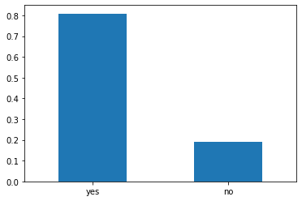

```python
ax = df_cat['is_business_account'].value_counts(1).plot.bar(x='target', rot=0)
```

```python
df_busi = pd.crosstab(posts_abt["is_business_account"],posts_abt["target"],margins=True)
df_busi['eng'] = df_busi[1]/df_busi['All']
df_busi
```

| target is_business_account | 0 | 1 | All | eng |
| --- | --- | --- | --- | --- |
| no | 486 | 56 | 542 | 0.103321 |
| yes | 1594 | 696 | 2290 | 0.303930 |
| All | 2080 | 752 | 2832 | 0.265537 |

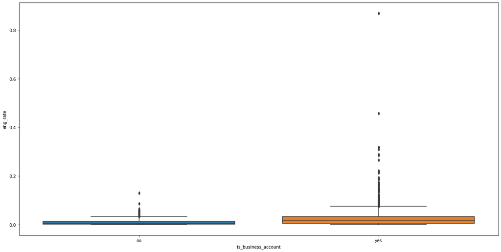

```python
fig, ax = plt.subplots(figsize=(20,10))
ax = sns.boxplot(x="is_business_account", y="eng_rate", data=posts_abt)
```

```python
pd.pivot_table(posts_abt, index=['is_business_account'],values=['eng_rate'], aggfunc=['size',
                                                                                          np.mean,
                                                                                          p25,
                                                                                          np.median,
                                                                                          p75,
                                                                                          np.min,
                                                                                          np.max,
                                                                                          np.std,])
```

| is_business_account | size 0 | mean eng_rate | p25 eng_rate | median eng_rate | p75 eng_rate | amin eng_rate | amax eng_rate | std eng_rate |
| --- | --- | --- | --- | --- | --- | --- | --- | --- |
| no | 542 | 0.010411 | 0.001856 | 0.004821 | 0.014388 | 0.00006 | 0.129496 | 0.013580 |
| yes | 2290 | 0.026200 | 0.005809 | 0.015669 | 0.033696 | 0.00000 | 0.868234 | 0.037327 |

##### cat_var: business_category_name

```python
# var: business_category_name

df_cat['business_category_name'].value_counts(1)
```

```
Personal Goods & General Merchandise Stores    0.478107
Creators & Celebrities                         0.265184
not defined                                    0.191384
Food & Personal Goods                          0.028249
General Interest                               0.010593
Business & Utility Services                    0.008828
Lifestyle Services                             0.008828
Home Services                                  0.008828
Name: business_category_name, dtype: float64
```

[output not shown]

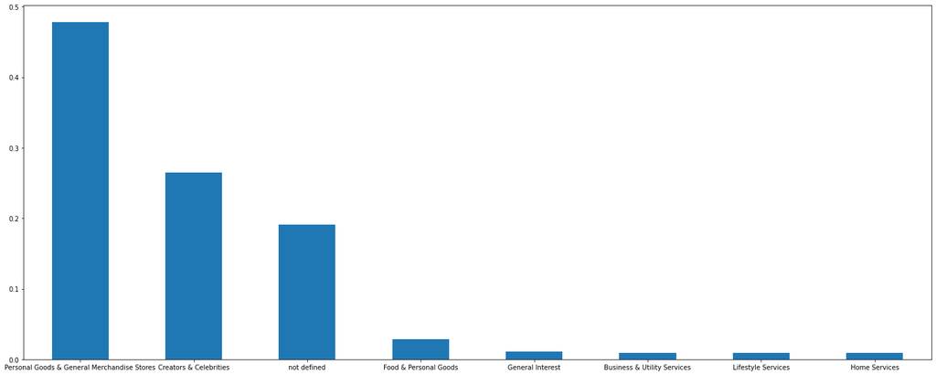

```python
fig, ax = plt.subplots(figsize=(25,10))
ax = df_cat['business_category_name'].value_counts(1).plot.bar(x='target', rot=0)
ax.set_xticklabels(ax.get_xmajorticklabels(), fontsize = 10)
```

```python
df_cat_name = pd.crosstab(posts_abt["business_category_name"],posts_abt["target"],margins=True)
df_cat_name['eng'] = df_cat_name[1]/df_cat_name['All']
df_cat_name
```

| target business_category_name | 0 | 1 | All | eng |
| --- | --- | --- | --- | --- |
| Business & Utility Services | 15 | 10 | 25 | 0.400000 |
| Creators & Celebrities | 476 | 275 | 751 | 0.366178 |
| Food & Personal Goods | 75 | 5 | 80 | 0.062500 |
| General Interest | 28 | 2 | 30 | 0.066667 |
| Home Services | 25 | 0 | 25 | 0.000000 |
| Lifestyle Services | 25 | 0 | 25 | 0.000000 |
| Personal Goods & General Merchandise Stores | 950 | 404 | 1354 | 0.298375 |
| not defined | 486 | 56 | 542 | 0.103321 |
| All | 2080 | 752 | 2832 | 0.265537 |

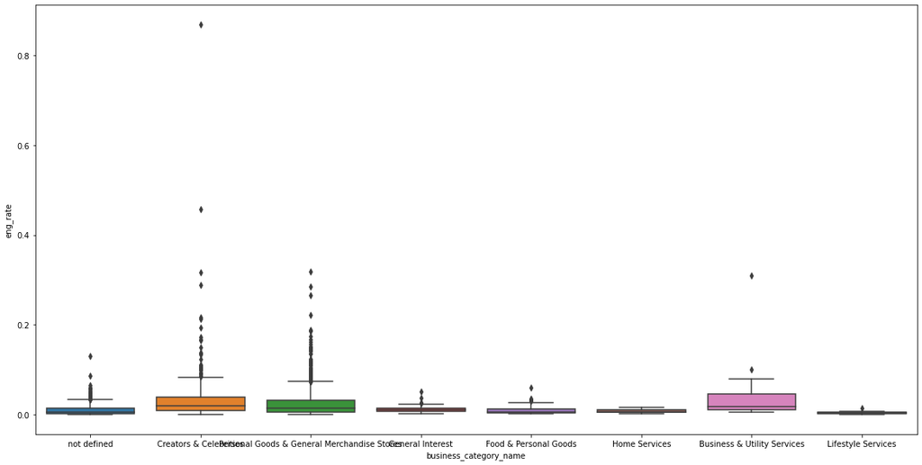

```python
fig, ax = plt.subplots(figsize=(20,10))
ax = sns.boxplot(x="business_category_name", y="eng_rate", data=posts_abt)
```

```python
pd.pivot_table(posts_abt, index=['business_category_name'],values=['eng_rate'], aggfunc=['size',
                                                                                          np.mean,
                                                                                          p25,
                                                                                          np.median,
                                                                                          p75,
                                                                                          np.min,
                                                                                          np.max,
                                                                                          np.std,])
```

| business_category_name | size 0 | mean eng_rate | p25 eng_rate | median eng_rate | p75 eng_rate | amin eng_rate | amax eng_rate | std eng_rate |
| --- | --- | --- | --- | --- | --- | --- | --- | --- |
| Business & Utility Services | 25 | 0.039592 | 0.011388 | 0.018260 | 0.046142 | 0.005890 | 0.309444 | 0.061227 |
| Creators & Celebrities | 751 | 0.030166 | 0.008680 | 0.019764 | 0.038533 | 0.000171 | 0.868234 | 0.046657 |
| Food & Personal Goods | 80 | 0.010647 | 0.004156 | 0.006197 | 0.013095 | 0.002405 | 0.059727 | 0.010021 |
| General Interest | 30 | 0.013317 | 0.007196 | 0.010034 | 0.014193 | 0.002905 | 0.050964 | 0.010479 |
| Home Services | 25 | 0.007477 | 0.004752 | 0.006336 | 0.010138 | 0.002693 | 0.016474 | 0.003615 |
| Lifestyle Services | 25 | 0.004427 | 0.001976 | 0.004388 | 0.005647 | 0.001124 | 0.014317 | 0.002999 |
| Personal Goods & General Merchandise Stores | 1354 | 0.025706 | 0.005244 | 0.014992 | 0.032679 | 0.000000 | 0.317916 | 0.032091 |
| not defined | 542 | 0.010411 | 0.001856 | 0.004821 | 0.014388 | 0.000060 | 0.129496 | 0.013580 |

##### cat_var: type

```python
# var: type

df_cat['type'].value_counts(1)
```

```
image      0.479873
sidecar    0.272246
video      0.247881
Name: type, dtype: float64
```

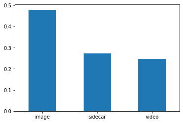

```python
#fig, ax = plt.subplots(figsize=(2,10))
ax = df_cat['type'].value_counts(1).plot.bar(x='target', rot=0)
#ax.set_xticklabels(ax.get_xmajorticklabels(), fontsize = 10)
```

```python
df_type = pd.crosstab(posts_abt["type"],posts_abt["target"],margins=True)
df_type['eng'] = df_type[1]/df_type['All']
df_type
```

| target type | 0 | 1 | All | eng |
| --- | --- | --- | --- | --- |
| image | 1048 | 311 | 1359 | 0.228845 |
| sidecar | 512 | 259 | 771 | 0.335927 |
| video | 520 | 182 | 702 | 0.259259 |
| All | 2080 | 752 | 2832 | 0.265537 |

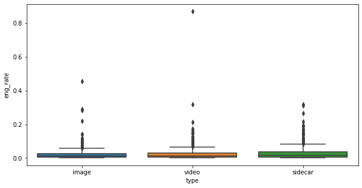

```python
fig, ax = plt.subplots(figsize=(10,5))
ax = sns.boxplot(x="type", y="eng_rate", data=posts_abt)
```

```python
pd.pivot_table(posts_abt, index=['type'],values=['eng_rate'], aggfunc=['size',
                                                                        np.mean,
                                                                        p25,
                                                                        np.median,
                                                                        p75,
                                                                        np.min,
                                                                        np.max,
                                                                        np.std,])
```

| type | size 0 | mean eng_rate | p25 eng_rate | median eng_rate | p75 eng_rate | amin eng_rate | amax eng_rate | std eng_rate |
| --- | --- | --- | --- | --- | --- | --- | --- | --- |
| image | 1359 | 0.019609 | 0.004029 | 0.012566 | 0.026212 | 0.000000 | 0.456311 | 0.026133 |
| sidecar | 771 | 0.029789 | 0.006675 | 0.017101 | 0.037398 | 0.000000 | 0.317916 | 0.037705 |
| video | 702 | 0.022829 | 0.003642 | 0.011043 | 0.029158 | 0.000148 | 0.868234 | 0.043477 |

##### cat_var: weekday

```python
# var: weekday

df_cat['weekday'].value_counts(1)
```

```
mon    0.169492
tue    0.165254
thu    0.164548
wed    0.154308
fri    0.145127
sat    0.117938
sun    0.083333
Name: weekday, dtype: float64
```

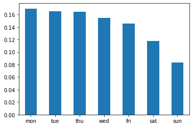

```python
#fig, ax = plt.subplots(figsize=(2,10))
ax = df_cat['weekday'].value_counts(1).plot.bar(x='target', rot=0)
#ax.set_xticklabels(ax.get_xmajorticklabels(), fontsize = 10)
```

```python
df_week = pd.crosstab(posts_abt["weekday"],posts_abt["target"],margins=True)
df_week['eng'] = df_week[1]/df_week['All']
df_week.sort_values(by='eng', ascending=False)
```

| target weekday | 0 | 1 | All | eng |
| --- | --- | --- | --- | --- |
| thu | 327 | 139 | 466 | 0.298283 |
| mon | 342 | 138 | 480 | 0.287500 |
| All | 2080 | 752 | 2832 | 0.265537 |
| sun | 174 | 62 | 236 | 0.262712 |
| fri | 306 | 105 | 411 | 0.255474 |
| wed | 327 | 110 | 437 | 0.251716 |
| tue | 352 | 116 | 468 | 0.247863 |
| sat | 252 | 82 | 334 | 0.245509 |

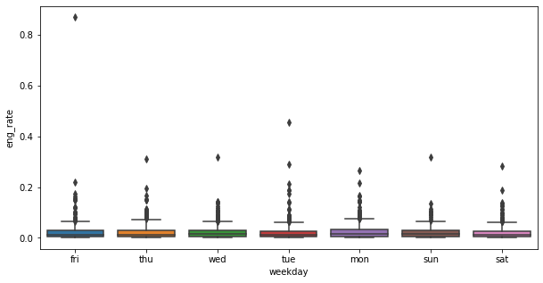

```python
fig, ax = plt.subplots(figsize=(10,5))
ax = sns.boxplot(x="weekday", y="eng_rate", data=posts_abt)
```

```python
pd.pivot_table(posts_abt, index=['weekday'],values=['eng_rate'], aggfunc=['size',
                                                                           np.mean,
                                                                           p25,
                                                                           np.median,
                                                                           p75,
                                                                           np.min,
                                                                           np.max,
                                                                           np.std,])
```

| weekday | size 0 | mean eng_rate | p25 eng_rate | median eng_rate | p75 eng_rate | amin eng_rate | amax eng_rate | std eng_rate |
| --- | --- | --- | --- | --- | --- | --- | --- | --- |
| fri | 411 | 0.024248 | 0.003829 | 0.011925 | 0.028771 | 0.000066 | 0.868234 | 0.050919 |
| mon | 480 | 0.023995 | 0.004631 | 0.014139 | 0.033054 | 0.000060 | 0.266234 | 0.030313 |
| sat | 334 | 0.021860 | 0.003738 | 0.011517 | 0.027130 | 0.000198 | 0.284211 | 0.030128 |
| sun | 236 | 0.022476 | 0.005178 | 0.014648 | 0.030245 | 0.000208 | 0.317391 | 0.029888 |
| thu | 466 | 0.023966 | 0.003686 | 0.013358 | 0.031250 | 0.000099 | 0.309444 | 0.031299 |
| tue | 468 | 0.023503 | 0.004880 | 0.013089 | 0.027830 | 0.000000 | 0.456311 | 0.035765 |
| wed | 437 | 0.021476 | 0.004569 | 0.013988 | 0.028534 | 0.000099 | 0.317916 | 0.027383 |

##### cat_var: time_range

```python
df_cat['time_range'].value_counts(1)
```

```
tarde        0.456215
manha        0.413489
noite        0.100282
madrugada    0.030014
Name: time_range, dtype: float64
```

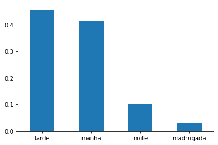

```python
#fig, ax = plt.subplots(figsize=(2,10))
ax = df_cat['time_range'].value_counts(1).plot.bar(x='target', rot=0)
#ax.set_xticklabels(ax.get_xmajorticklabels(), fontsize = 10)
```

```python
df_range = pd.crosstab(posts_abt["time_range"],posts_abt["target"],margins=True)
df_range['eng'] = df_range[1]/df_range['All']
df_range.sort_values(by='eng', ascending=False)
```

| target time_range | 0 | 1 | All | eng |
| --- | --- | --- | --- | --- |
| tarde | 920 | 372 | 1292 | 0.287926 |
| noite | 206 | 78 | 284 | 0.274648 |
| All | 2080 | 752 | 2832 | 0.265537 |
| madrugada | 63 | 22 | 85 | 0.258824 |
| manha | 891 | 280 | 1171 | 0.239112 |

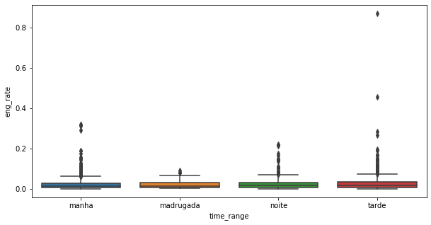

```python
fig, ax = plt.subplots(figsize=(10,5))
ax = sns.boxplot(x="time_range", y="eng_rate", data=posts_abt)
```

```python
pd.pivot_table(posts_abt, index=['time_range'],values=['eng_rate'], aggfunc=['size',
                                                                             np.mean,
                                                                             p25,
                                                                             np.median,
                                                                             p75,
                                                                             np.min,
                                                                             np.max,
                                                                             np.std,])
```

| time_range | size 0 | mean eng_rate | p25 eng_rate | median eng_rate | p75 eng_rate | amin eng_rate | amax eng_rate | std eng_rate |
| --- | --- | --- | --- | --- | --- | --- | --- | --- |
| madrugada | 85 | 0.019870 | 0.004646 | 0.012800 | 0.029973 | 0.000477 | 0.091304 | 0.020358 |
| manha | 1171 | 0.020714 | 0.003889 | 0.010931 | 0.027111 | 0.000066 | 0.317916 | 0.029472 |
| noite | 284 | 0.024944 | 0.003871 | 0.014490 | 0.029405 | 0.000000 | 0.220942 | 0.035343 |
| tarde | 1292 | 0.025242 | 0.004994 | 0.014812 | 0.032294 | 0.000099 | 0.868234 | 0.039155 |

### Variáveis numéricas

```python
df_num.describe()
```

|  | followed_by_count | follows_count | media_count | comments_count | likes_count | eng_rate | target | hour | caption_count | caption_tag | caption_hash |
| --- | --- | --- | --- | --- | --- | --- | --- | --- | --- | --- | --- |
| count | 2832.000000 | 2832.000000 | 2832.000000 | 2832.000000 | 2832.000000 | 2832.000000 | 2832.000000 | 2832.000000 | 2832.000000 | 2832.000000 | 2832.000000 |
| mean | 32134.034251 | 1346.998234 | 699.330155 | 54.646893 | 279.486935 | 0.023179 | 0.265537 | 12.290960 | 264.266243 | 0.185381 | 5.198799 |
| std | 63647.135210 | 1771.679290 | 1255.463340 | 930.644582 | 866.851873 | 0.034646 | 0.441697 | 4.107366 | 218.747763 | 0.614690 | 5.690879 |
| min | 78.000000 | 1.000000 | 12.000000 | 0.000000 | 0.000000 | 0.000000 | 0.000000 | 0.000000 | 0.000000 | 0.000000 | 0.000000 |
| 25% | 821.000000 | 134.000000 | 134.000000 | 0.000000 | 18.000000 | 0.004341 | 0.000000 | 9.000000 | 120.000000 | 0.000000 | 0.000000 |
| 50% | 6274.000000 | 576.000000 | 319.000000 | 2.000000 | 50.000000 | 0.013083 | 0.000000 | 12.000000 | 215.000000 | 0.000000 | 4.000000 |
| 75% | 30269.000000 | 1610.000000 | 851.000000 | 9.000000 | 182.250000 | 0.029601 | 1.000000 | 16.000000 | 349.250000 | 0.000000 | 8.000000 |
| max | 364602.000000 | 7500.000000 | 9547.000000 | 43127.000000 | 14648.000000 | 0.868234 | 1.000000 | 23.000000 | 2080.000000 | 14.000000 | 30.000000 |

##### num_var: followed_by_count

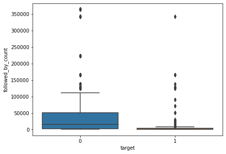

```python
fig, ax = plt.subplots(figsize=(7,5))
ax = sns.boxplot(x="target", y="followed_by_count", data=posts_abt)
```

```python
pd.pivot_table(posts_abt, index=['target'],values=['followed_by_count'], aggfunc=['size',
                                                                             np.mean,
                                                                             p25,
                                                                             np.median,
                                                                             p75,
                                                                             np.min,
                                                                             np.max,
                                                                             np.std,])
```

| target | size 0 | mean followed_by_count | p25 followed_by_count | median followed_by_count | p75 followed_by_count | amin followed_by_count | amax followed_by_count | std followed_by_count |
| --- | --- | --- | --- | --- | --- | --- | --- | --- |
| 0 | 2080 | 40803.787500 | 2303.25 | 15125 | 50916 | 78 | 364602 | 70128.392425 |
| 1 | 752 | 8153.865691 | 362.00 | 684 | 3444 | 78 | 342715 | 29532.048231 |

- Não necessariamente aquelas que são tem mais seguidores que são as mais engajadas.
- Boxplot dos shops engajados ficou bem achatado.

##### num_var: follows_count

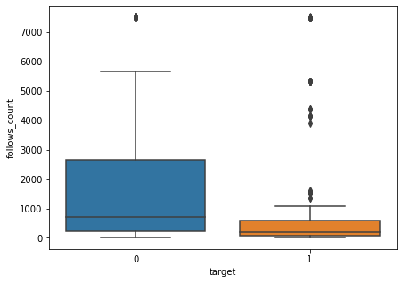

```python
fig, ax = plt.subplots(figsize=(7,5))
ax = sns.boxplot(x="target", y="follows_count", data=posts_abt)
```

```python
pd.pivot_table(posts_abt, index=['target'],values=['follows_count'], aggfunc=['size',
                                                                             np.mean,
                                                                             p25,
                                                                             np.median,
                                                                             p75,
                                                                             np.min,
                                                                             np.max,
                                                                             np.std,])
```

| target | size 0 | mean follows_count | p25 follows_count | median follows_count | p75 follows_count | amin follows_count | amax follows_count | std follows_count |
| --- | --- | --- | --- | --- | --- | --- | --- | --- |
| 0 | 2080 | 1569.773558 | 235 | 722 | 2664 | 1 | 7500 | 1784.296810 |
| 1 | 752 | 730.811170 | 81 | 193 | 576 | 1 | 7500 | 1581.509898 |

- O volume de perfis que a papelaria segue não parece influenciar tanto.

##### num_var: media_count

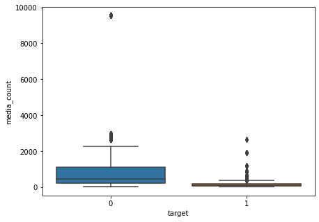

```python
fig, ax = plt.subplots(figsize=(7,5))
ax = sns.boxplot(x="target", y="media_count", data=posts_abt)
```

```python
pd.pivot_table(posts_abt, index=['target'],values=['media_count'], aggfunc=['size',
                                                                             np.mean,
                                                                             p25,
                                                                             np.median,
                                                                             p75,
                                                                             np.min,
                                                                             np.max,
                                                                             np.std,])
```

| target | size 0 | mean media_count | p25 media_count | median media_count | p75 media_count | amin media_count | amax media_count | std media_count |
| --- | --- | --- | --- | --- | --- | --- | --- | --- |
| 0 | 2080 | 888.301923 | 204 | 435 | 1094 | 19 | 9547 | 1409.279750 |
| 1 | 752 | 176.642287 | 59 | 99 | 188 | 12 | 2662 | 266.717061 |

- Quantidade de posts parece não impactar tanto de forma isolada.

##### num_var: comments_count

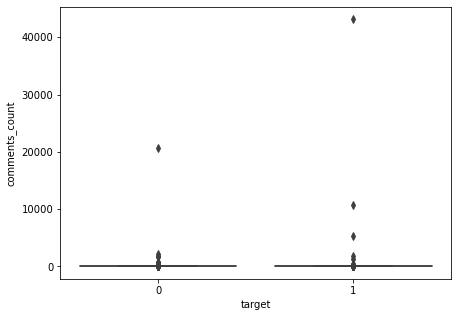

```python
fig, ax = plt.subplots(figsize=(7,5))
ax = sns.boxplot(x="target", y="comments_count", data=posts_abt)
```

```python
pd.pivot_table(posts_abt, index=['target'],values=['comments_count'], aggfunc=['size',
                                                                             np.mean,
                                                                             p25,
                                                                             np.median,
                                                                             p75,
                                                                             p90,
                                                                             np.min,
                                                                             np.max,
                                                                             np.std,])
```

| target | size 0 | mean comments_count | p25 comments_count | median comments_count | p75 comments_count | p90 comments_count | amin comments_count | amax comments_count | std comments_count |
| --- | --- | --- | --- | --- | --- | --- | --- | --- | --- |
| 0 | 2080 | 40.724038 | 0 | 2 | 9 | 57.2 | 0 | 20593 | 464.237275 |
| 1 | 752 | 93.156915 | 0 | 2 | 8 | 22.0 | 0 | 43127 | 1632.864261 |

- Posts do tipo "sorteio" impactam bastante nessa feature.

##### num_var: likes_count

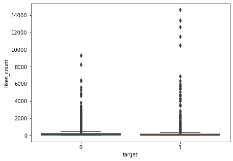

```python
fig, ax = plt.subplots(figsize=(7,5))
ax = sns.boxplot(x="target", y="likes_count", data=posts_abt)
```

```python
pd.pivot_table(posts_abt, index=['target'],values=['likes_count'], aggfunc=['size',
                                                                             np.mean,
                                                                             p25,
                                                                             np.median,
                                                                             p75,
                                                                             np.min,
                                                                             np.max,
                                                                             np.std,])
```

| target | size 0 | mean likes_count | p25 likes_count | median likes_count | p75 likes_count | amin likes_count | amax likes_count | std likes_count |
| --- | --- | --- | --- | --- | --- | --- | --- | --- |
| 0 | 2080 | 237.485577 | 19 | 58 | 191.00 | 0 | 9339 | 603.240084 |
| 1 | 752 | 395.660904 | 17 | 33 | 152.25 | 3 | 14648 | 1344.189370 |

- Analisando isoladamente o número de seguidores e likes, não é possível afirmar os shops que terão engajamento.
- Por isso é importante olhar a taxa e outras features que podem impactar.

##### num_var: hour

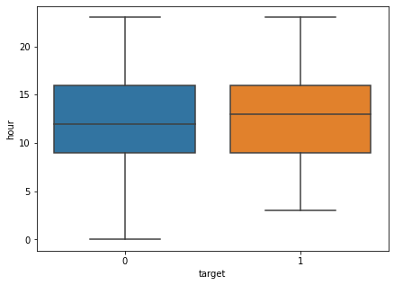

```python
fig, ax = plt.subplots(figsize=(7,5))
ax = sns.boxplot(x="target", y="hour", data=posts_abt)
```

```python
pd.pivot_table(posts_abt, index=['target'],values=['hour'], aggfunc=['size',
                                                                             np.mean,
                                                                             p25,
                                                                             np.median,
                                                                             p75,
                                                                             p90,
                                                                             np.min,
                                                                             np.max,
                                                                             np.std,])
```

| target | size 0 | mean hour | p25 hour | median hour | p75 hour | p90 hour | amin hour | amax hour | std hour |
| --- | --- | --- | --- | --- | --- | --- | --- | --- | --- |
| 0 | 2080 | 12.214904 | 9 | 12 | 16 | 17 | 0 | 23 | 4.11177 |
| 1 | 752 | 12.501330 | 9 | 13 | 16 | 18 | 3 | 23 | 4.09052 |

- Variável de horas não trouxe muitos insights relevantes.
- 75% dos posts são realizados até 16h.
- 90% dos posts são realizados até 18h.

##### num_var: caption_count

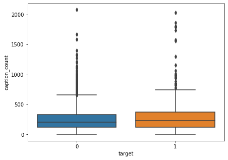

```python
fig, ax = plt.subplots(figsize=(7,5))
ax = sns.boxplot(x="target", y="caption_count", data=posts_abt)
```

```python
pd.pivot_table(posts_abt, index=['target'],values=['caption_count'], aggfunc=['size',
                                                                             np.mean,
                                                                             p25,
                                                                             np.median,
                                                                             p75,
                                                                             np.min,
                                                                             np.max,
                                                                             np.std,])
```

| target | size 0 | mean caption_count | p25 caption_count | median caption_count | p75 caption_count | amin caption_count | amax caption_count | std caption_count |
| --- | --- | --- | --- | --- | --- | --- | --- | --- |
| 0 | 2080 | 256.946154 | 119.00 | 208.5 | 335 | 0 | 2080 | 207.121052 |
| 1 | 752 | 284.513298 | 122.75 | 229.5 | 376 | 0 | 2030 | 247.108390 |

- Quantidade de caracteres da descrição do post pode influenciar.

##### num_var: caption_tag

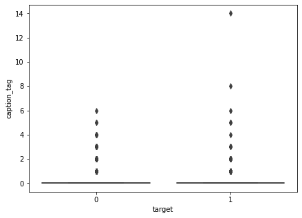

```python
fig, ax = plt.subplots(figsize=(7,5))
ax = sns.boxplot(x="target", y="caption_tag", data=posts_abt)
```

```python
pd.pivot_table(posts_abt, index=['target'],values=['caption_tag'], aggfunc=['size',
                                                                             np.mean,
                                                                             p25,
                                                                             np.median,
                                                                             p75,
                                                                             np.min,
                                                                             np.max,
                                                                             np.std,])
```

| target | size 0 | mean caption_tag | p25 caption_tag | median caption_tag | p75 caption_tag | amin caption_tag | amax caption_tag | std caption_tag |
| --- | --- | --- | --- | --- | --- | --- | --- | --- |
| 0 | 2080 | 0.177885 | 0 | 0 | 0 | 0 | 6 | 0.525530 |
| 1 | 752 | 0.206117 | 0 | 0 | 0 | 0 | 14 | 0.811905 |

- Marcações no na descrição do post parecem não influenciar tanto no engajamento.

##### num_var: caption_hash

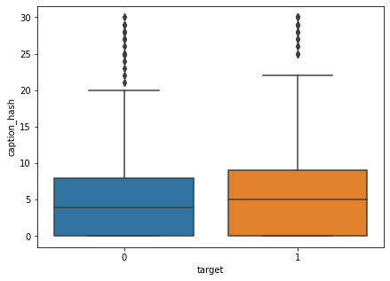

```python
fig, ax = plt.subplots(figsize=(7,5))
ax = sns.boxplot(x="target", y="caption_hash", data=posts_abt)
```

```python
pd.pivot_table(posts_abt, index=['target'],values=['caption_hash'], aggfunc=['size',
                                                                             np.mean,
                                                                             p25,
                                                                             np.median,
                                                                             p75,
                                                                             np.min,
                                                                             np.max,
                                                                             np.std,])
```

| target | size 0 | mean caption_hash | p25 caption_hash | median caption_hash | p75 caption_hash | amin caption_hash | amax caption_hash | std caption_hash |
| --- | --- | --- | --- | --- | --- | --- | --- | --- |
| 0 | 2080 | 4.884615 | 0 | 4 | 8 | 0 | 30 | 5.423672 |
| 1 | 752 | 6.067819 | 0 | 5 | 9 | 0 | 30 | 6.294539 |

- Quantidade de hashtags parece realmente influenciar no engajamento

### Normalizando variáveis numéricas

```python
v_num = ['followed_by_count',
         'follows_count',
         'media_count',
         'comments_count',
         'likes_count',
         #'eng_rate',
         'target',
         'hour',
         'caption_count',
         'caption_tag',
         'caption_hash']
```

```python
df_num_corr = df_num.drop(columns='eng_rate')
```

```python
from feature_engine.wrappers import SklearnTransformerWrapper
from sklearn.preprocessing import StandardScaler

std_scaler = SklearnTransformerWrapper(transformer = StandardScaler(),
                                       variables = ['followed_by_count',
                                                    'follows_count',
                                                    'media_count',
                                                    'comments_count',
                                                    'likes_count',
                                                    'target',
                                                    'hour',
                                                    'caption_count',
                                                    'caption_tag',
                                                    'caption_hash'
                                                   ])

std_scaler.fit(df_num_corr)
df_num_corr = std_scaler.transform(df_num_corr)
df_num_corr
```

|  | followed_by_count | follows_count | media_count | comments_count | likes_count | target | hour | caption_count | caption_tag | caption_hash |
| --- | --- | --- | --- | --- | --- | --- | --- | --- | --- | --- |
| 0 | 0.438148 | -0.412110 | 1.814527 | -0.056580 | -0.272859 | -0.601281 | -1.044883 | -0.792222 | -0.301639 | -0.913693 |
| 1 | 0.438148 | -0.412110 | 1.814527 | -0.055506 | -0.241707 | -0.601281 | -2.018916 | -0.289271 | -0.301639 | 0.140812 |
| 2 | 0.438148 | -0.412110 | 1.814527 | -0.051207 | -0.305166 | -0.601281 | 1.390197 | -0.549891 | -0.301639 | -0.034939 |
| 3 | 0.438148 | -0.412110 | 1.814527 | -0.054431 | -0.260168 | -0.601281 | 0.659673 | -0.403578 | -0.301639 | 0.140812 |
| 4 | 0.438148 | -0.412110 | 1.814527 | -0.047983 | -0.294782 | -0.601281 | 0.903181 | 0.506306 | -0.301639 | 2.601323 |
| ... | ... | ... | ... | ... | ... | ... | ... | ... | ... | ... |
| 2830 | 0.414278 | 0.526713 | 0.582892 | -0.058730 | -0.219784 | -0.601281 | -0.801375 | 1.772828 | -0.301639 | 0.843815 |
| 2831 | 0.414278 | 0.526713 | 0.582892 | -0.051207 | -0.023638 | -0.601281 | 1.146689 | 1.375040 | -0.301639 | 0.843815 |
| 2832 | 0.414278 | 0.526713 | 0.582892 | -0.056580 | -0.184017 | -0.601281 | 0.659673 | 1.631088 | -0.301639 | 0.843815 |
| 2833 | 0.414278 | 0.526713 | 0.582892 | -0.045833 | -0.151710 | -0.601281 | 1.146689 | 1.306455 | -0.301639 | 0.843815 |
| 2834 | 0.414278 | 0.526713 | 0.582892 | -0.052281 | -0.208246 | -0.601281 | 0.659673 | 2.449526 | -0.301639 | 0.843815 |

2832 rows × 10 columns

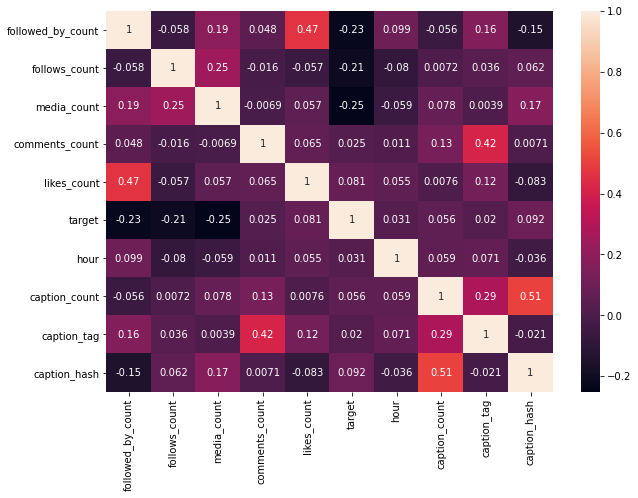

```python
# plotting correlation heatmap
import matplotlib.pyplot as mp
fig, ax = plt.subplots(figsize=(10,7))
dataplot = sns.heatmap(df_num_corr.corr(), annot=True)

# displaying heatmap
mp.show()
```

Pontos interessantes:

- Correlação entre marcações e comentários. Apostar melhor nisso.
- Óbvio: quanto maior o número de seguidores, maior as curtidas.
- Correlação inversa entre likes e número de pessoas que segue. Não influencia tanto.
- Hashtags não parece influenciar tanto para perfis com muitos seguidores
- Isoladamente, seguidores, seguidos e número de posts não mostram engajamento. É essencial uma boa combinação de fatores.

## Clustering

```python
df_cat.info()
```

```
<class 'pandas.core.frame.DataFrame'>
Int64Index: 2832 entries, 0 to 2834
Data columns (total 5 columns):
 #   Column                  Non-Null Count  Dtype
---  ------                  --------------  -----
 0   is_business_account     2832 non-null   object
 1   business_category_name  2832 non-null   object
 2   type                    2832 non-null   object
 3   weekday                 2832 non-null   object
 4   time_range              2832 non-null   object
dtypes: object(5)
memory usage: 212.8+ KB
```

```python
from feature_engine.encoding import OneHotEncoder
ohe = OneHotEncoder(variables=['is_business_account','business_category_name','type', 'weekday', 'time_range'])
ohe.fit(df_cat)
v_cat = ohe.transform(df_cat)
v_cat
```

|  | is_business_account_no | is_business_account_yes | business_category_name_not defined | business_category_name_Creators & Celebrities | business_category_name_Personal Goods & General Merchandise Stores | business_category_name_General Interest | business_category_name_Food & Personal Goods | business_category_name_Home Services | business_category_name_Business & Utility Services | business_category_name_Lifestyle Services | ... | weekday_thu | weekday_wed | weekday_tue | weekday_mon | weekday_sun | weekday_sat | time_range_manha | time_range_madrugada | time_range_noite | time_range_tarde |
| --- | --- | --- | --- | --- | --- | --- | --- | --- | --- | --- | --- | --- | --- | --- | --- | --- | --- | --- | --- | --- | --- |
| 0 | 1 | 0 | 1 | 0 | 0 | 0 | 0 | 0 | 0 | 0 | ... | 0 | 0 | 0 | 0 | 0 | 0 | 1 | 0 | 0 | 0 |
| 1 | 1 | 0 | 1 | 0 | 0 | 0 | 0 | 0 | 0 | 0 | ... | 0 | 0 | 0 | 0 | 0 | 0 | 0 | 1 | 0 | 0 |
| 2 | 1 | 0 | 1 | 0 | 0 | 0 | 0 | 0 | 0 | 0 | ... | 1 | 0 | 0 | 0 | 0 | 0 | 0 | 0 | 1 | 0 |
| 3 | 1 | 0 | 1 | 0 | 0 | 0 | 0 | 0 | 0 | 0 | ... | 1 | 0 | 0 | 0 | 0 | 0 | 0 | 0 | 0 | 1 |
| 4 | 1 | 0 | 1 | 0 | 0 | 0 | 0 | 0 | 0 | 0 | ... | 0 | 1 | 0 | 0 | 0 | 0 | 0 | 0 | 0 | 1 |
| ... | ... | ... | ... | ... | ... | ... | ... | ... | ... | ... | ... | ... | ... | ... | ... | ... | ... | ... | ... | ... | ... |
| 2830 | 0 | 1 | 0 | 0 | 1 | 0 | 0 | 0 | 0 | 0 | ... | 0 | 1 | 0 | 0 | 0 | 0 | 1 | 0 | 0 | 0 |
| 2831 | 0 | 1 | 0 | 0 | 1 | 0 | 0 | 0 | 0 | 0 | ... | 0 | 0 | 1 | 0 | 0 | 0 | 0 | 0 | 0 | 1 |
| 2832 | 0 | 1 | 0 | 0 | 1 | 0 | 0 | 0 | 0 | 0 | ... | 0 | 0 | 1 | 0 | 0 | 0 | 0 | 0 | 0 | 1 |
| 2833 | 0 | 1 | 0 | 0 | 1 | 0 | 0 | 0 | 0 | 0 | ... | 0 | 0 | 0 | 1 | 0 | 0 | 0 | 0 | 0 | 1 |
| 2834 | 0 | 1 | 0 | 0 | 1 | 0 | 0 | 0 | 0 | 0 | ... | 0 | 0 | 0 | 1 | 0 | 0 | 0 | 0 | 0 | 1 |

2832 rows × 24 columns

```python
vars_modif = pd.concat([v_cat, df_num_corr], axis='columns')
vars_modif
```

|  | is_business_account_no | is_business_account_yes | business_category_name_not defined | business_category_name_Creators & Celebrities | business_category_name_Personal Goods & General Merchandise Stores | business_category_name_General Interest | business_category_name_Food & Personal Goods | business_category_name_Home Services | business_category_name_Business & Utility Services | business_category_name_Lifestyle Services | ... | followed_by_count | follows_count | media_count | comments_count | likes_count | target | hour | caption_count | caption_tag | caption_hash |
| --- | --- | --- | --- | --- | --- | --- | --- | --- | --- | --- | --- | --- | --- | --- | --- | --- | --- | --- | --- | --- | --- |
| 0 | 1 | 0 | 1 | 0 | 0 | 0 | 0 | 0 | 0 | 0 | ... | 0.438148 | -0.412110 | 1.814527 | -0.056580 | -0.272859 | -0.601281 | -1.044883 | -0.792222 | -0.301639 | -0.913693 |
| 1 | 1 | 0 | 1 | 0 | 0 | 0 | 0 | 0 | 0 | 0 | ... | 0.438148 | -0.412110 | 1.814527 | -0.055506 | -0.241707 | -0.601281 | -2.018916 | -0.289271 | -0.301639 | 0.140812 |
| 2 | 1 | 0 | 1 | 0 | 0 | 0 | 0 | 0 | 0 | 0 | ... | 0.438148 | -0.412110 | 1.814527 | -0.051207 | -0.305166 | -0.601281 | 1.390197 | -0.549891 | -0.301639 | -0.034939 |
| 3 | 1 | 0 | 1 | 0 | 0 | 0 | 0 | 0 | 0 | 0 | ... | 0.438148 | -0.412110 | 1.814527 | -0.054431 | -0.260168 | -0.601281 | 0.659673 | -0.403578 | -0.301639 | 0.140812 |
| 4 | 1 | 0 | 1 | 0 | 0 | 0 | 0 | 0 | 0 | 0 | ... | 0.438148 | -0.412110 | 1.814527 | -0.047983 | -0.294782 | -0.601281 | 0.903181 | 0.506306 | -0.301639 | 2.601323 |
| ... | ... | ... | ... | ... | ... | ... | ... | ... | ... | ... | ... | ... | ... | ... | ... | ... | ... | ... | ... | ... | ... |
| 2830 | 0 | 1 | 0 | 0 | 1 | 0 | 0 | 0 | 0 | 0 | ... | 0.414278 | 0.526713 | 0.582892 | -0.058730 | -0.219784 | -0.601281 | -0.801375 | 1.772828 | -0.301639 | 0.843815 |
| 2831 | 0 | 1 | 0 | 0 | 1 | 0 | 0 | 0 | 0 | 0 | ... | 0.414278 | 0.526713 | 0.582892 | -0.051207 | -0.023638 | -0.601281 | 1.146689 | 1.375040 | -0.301639 | 0.843815 |
| 2832 | 0 | 1 | 0 | 0 | 1 | 0 | 0 | 0 | 0 | 0 | ... | 0.414278 | 0.526713 | 0.582892 | -0.056580 | -0.184017 | -0.601281 | 0.659673 | 1.631088 | -0.301639 | 0.843815 |
| 2833 | 0 | 1 | 0 | 0 | 1 | 0 | 0 | 0 | 0 | 0 | ... | 0.414278 | 0.526713 | 0.582892 | -0.045833 | -0.151710 | -0.601281 | 1.146689 | 1.306455 | -0.301639 | 0.843815 |
| 2834 | 0 | 1 | 0 | 0 | 1 | 0 | 0 | 0 | 0 | 0 | ... | 0.414278 | 0.526713 | 0.582892 | -0.052281 | -0.208246 | -0.601281 | 0.659673 | 2.449526 | -0.301639 | 0.843815 |

2832 rows × 34 columns

```python
vars_modif
```

|  | is_business_account_no | is_business_account_yes | business_category_name_not defined | business_category_name_Creators & Celebrities | business_category_name_Personal Goods & General Merchandise Stores | business_category_name_General Interest | business_category_name_Food & Personal Goods | business_category_name_Home Services | business_category_name_Business & Utility Services | business_category_name_Lifestyle Services | ... | followed_by_count | follows_count | media_count | comments_count | likes_count | target | hour | caption_count | caption_tag | caption_hash |
| --- | --- | --- | --- | --- | --- | --- | --- | --- | --- | --- | --- | --- | --- | --- | --- | --- | --- | --- | --- | --- | --- |
| 0 | 1 | 0 | 1 | 0 | 0 | 0 | 0 | 0 | 0 | 0 | ... | 0.438148 | -0.412110 | 1.814527 | -0.056580 | -0.272859 | -0.601281 | -1.044883 | -0.792222 | -0.301639 | -0.913693 |
| 1 | 1 | 0 | 1 | 0 | 0 | 0 | 0 | 0 | 0 | 0 | ... | 0.438148 | -0.412110 | 1.814527 | -0.055506 | -0.241707 | -0.601281 | -2.018916 | -0.289271 | -0.301639 | 0.140812 |
| 2 | 1 | 0 | 1 | 0 | 0 | 0 | 0 | 0 | 0 | 0 | ... | 0.438148 | -0.412110 | 1.814527 | -0.051207 | -0.305166 | -0.601281 | 1.390197 | -0.549891 | -0.301639 | -0.034939 |
| 3 | 1 | 0 | 1 | 0 | 0 | 0 | 0 | 0 | 0 | 0 | ... | 0.438148 | -0.412110 | 1.814527 | -0.054431 | -0.260168 | -0.601281 | 0.659673 | -0.403578 | -0.301639 | 0.140812 |
| 4 | 1 | 0 | 1 | 0 | 0 | 0 | 0 | 0 | 0 | 0 | ... | 0.438148 | -0.412110 | 1.814527 | -0.047983 | -0.294782 | -0.601281 | 0.903181 | 0.506306 | -0.301639 | 2.601323 |
| ... | ... | ... | ... | ... | ... | ... | ... | ... | ... | ... | ... | ... | ... | ... | ... | ... | ... | ... | ... | ... | ... |
| 2830 | 0 | 1 | 0 | 0 | 1 | 0 | 0 | 0 | 0 | 0 | ... | 0.414278 | 0.526713 | 0.582892 | -0.058730 | -0.219784 | -0.601281 | -0.801375 | 1.772828 | -0.301639 | 0.843815 |
| 2831 | 0 | 1 | 0 | 0 | 1 | 0 | 0 | 0 | 0 | 0 | ... | 0.414278 | 0.526713 | 0.582892 | -0.051207 | -0.023638 | -0.601281 | 1.146689 | 1.375040 | -0.301639 | 0.843815 |
| 2832 | 0 | 1 | 0 | 0 | 1 | 0 | 0 | 0 | 0 | 0 | ... | 0.414278 | 0.526713 | 0.582892 | -0.056580 | -0.184017 | -0.601281 | 0.659673 | 1.631088 | -0.301639 | 0.843815 |
| 2833 | 0 | 1 | 0 | 0 | 1 | 0 | 0 | 0 | 0 | 0 | ... | 0.414278 | 0.526713 | 0.582892 | -0.045833 | -0.151710 | -0.601281 | 1.146689 | 1.306455 | -0.301639 | 0.843815 |
| 2834 | 0 | 1 | 0 | 0 | 1 | 0 | 0 | 0 | 0 | 0 | ... | 0.414278 | 0.526713 | 0.582892 | -0.052281 | -0.208246 | -0.601281 | 0.659673 | 2.449526 | -0.301639 | 0.843815 |

2832 rows × 34 columns

```python
# Base utilizada será com variáveis categóricas e numéricas modificadas

df_cluster = posts_abt
cluster = vars_modif.drop(columns=['target'])
```

```python
cluster.head()
```

|  | is_business_account_no | is_business_account_yes | business_category_name_not defined | business_category_name_Creators & Celebrities | business_category_name_Personal Goods & General Merchandise Stores | business_category_name_General Interest | business_category_name_Food & Personal Goods | business_category_name_Home Services | business_category_name_Business & Utility Services | business_category_name_Lifestyle Services | ... | time_range_tarde | followed_by_count | follows_count | media_count | comments_count | likes_count | hour | caption_count | caption_tag | caption_hash |
| --- | --- | --- | --- | --- | --- | --- | --- | --- | --- | --- | --- | --- | --- | --- | --- | --- | --- | --- | --- | --- | --- |
| 0 | 1 | 0 | 1 | 0 | 0 | 0 | 0 | 0 | 0 | 0 | ... | 0 | 0.438148 | -0.41211 | 1.814527 | -0.056580 | -0.272859 | -1.044883 | -0.792222 | -0.301639 | -0.913693 |
| 1 | 1 | 0 | 1 | 0 | 0 | 0 | 0 | 0 | 0 | 0 | ... | 0 | 0.438148 | -0.41211 | 1.814527 | -0.055506 | -0.241707 | -2.018916 | -0.289271 | -0.301639 | 0.140812 |
| 2 | 1 | 0 | 1 | 0 | 0 | 0 | 0 | 0 | 0 | 0 | ... | 0 | 0.438148 | -0.41211 | 1.814527 | -0.051207 | -0.305166 | 1.390197 | -0.549891 | -0.301639 | -0.034939 |
| 3 | 1 | 0 | 1 | 0 | 0 | 0 | 0 | 0 | 0 | 0 | ... | 1 | 0.438148 | -0.41211 | 1.814527 | -0.054431 | -0.260168 | 0.659673 | -0.403578 | -0.301639 | 0.140812 |
| 4 | 1 | 0 | 1 | 0 | 0 | 0 | 0 | 0 | 0 | 0 | ... | 1 | 0.438148 | -0.41211 | 1.814527 | -0.047983 | -0.294782 | 0.903181 | 0.506306 | -0.301639 | 2.601323 |

5 rows × 33 columns

```python
cluster.shape
```

```
(2832, 33)
```

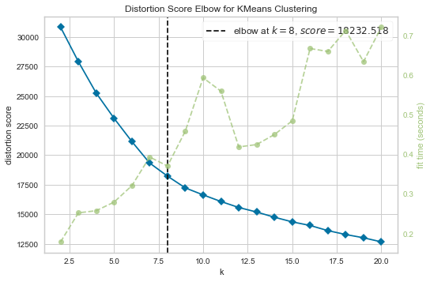

```python
from sklearn.cluster import KMeans
from yellowbrick.cluster import KElbowVisualizer

kmeans = KMeans(random_state=15)
visualizer = KElbowVisualizer(kmeans, k=(2, 21))
visualizer.fit(cluster)
visualizer.show()
```

```python
kmeans = KMeans(n_clusters=5, random_state=15)
kmeans.fit(cluster)
df_cluster['cluster_categorias'] = kmeans.labels_
df_cluster.head()
```

|  | link | account_name | is_business_account | business_category_name | followed_by_count | follows_count | media_count | comments_count | likes_count | type | eng_rate | target | weekday | hour | time_range | caption_count | caption_tag | caption_hash | cluster_categorias |
| --- | --- | --- | --- | --- | --- | --- | --- | --- | --- | --- | --- | --- | --- | --- | --- | --- | --- | --- | --- |
| 0 | https://www.instagram.com/p/CShD4lTLE2C | papelarialiane | no | not defined | 60016 | 617 | 2977 | 2 | 43 | image | 0.000716 | 0 | fri | 8 | manha | 91 | 0 | 0 | 0 |
| 1 | https://www.instagram.com/p/CSgsvz_rV1B | papelarialiane | no | not defined | 60016 | 617 | 2977 | 3 | 70 | image | 0.001166 | 0 | fri | 4 | madrugada | 201 | 0 | 6 | 0 |
| 2 | https://www.instagram.com/p/CSfjFF1H7zV | papelarialiane | no | not defined | 60016 | 617 | 2977 | 7 | 15 | video | 0.000250 | 0 | thu | 18 | noite | 144 | 0 | 5 | 1 |
| 3 | https://www.instagram.com/p/CSfP3jtrbLQ | papelarialiane | no | not defined | 60016 | 617 | 2977 | 4 | 54 | sidecar | 0.000900 | 0 | thu | 15 | tarde | 176 | 0 | 6 | 1 |
| 4 | https://www.instagram.com/p/CScyNG7H_FX | papelarialiane | no | not defined | 60016 | 617 | 2977 | 10 | 24 | video | 0.000400 | 0 | wed | 16 | tarde | 375 | 0 | 20 | 1 |

```python
#sns.scatterplot(data=df_cluster, x='cluster_categorias', y='hour', hue='caption_count', s=50, palette='deep');
```

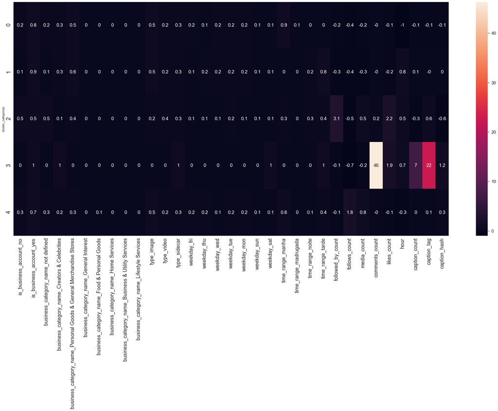

```python
# Avaliando a clusterização

import matplotlib.pyplot as plt
import seaborn as sns

fig, ax = plt.subplots(figsize=(34, 15))
ax.set_xticklabels(ax.get_xmajorticklabels(), fontsize = 20)
ax.set_xticklabels(ax.get_xmajorticklabels(), fontsize = 18, rotation=45)
ax.set_yticklabels(ax.get_ymajorticklabels(), fontsize = 20)
sns.set(font_scale=1.4)


tabulacao = cluster.groupby(df_cluster['cluster_categorias']).mean().round(1)


sns.heatmap(tabulacao, annot=True);
```

```python
df_cluster['cluster_categorias'].value_counts()
```

```
1    1216
0     883
4     555
2     177
3       1
Name: cluster_categorias, dtype: int64
```

```python
df_cluster['cluster_categorias'].value_counts(1)
```

```
1    0.429379
0    0.311794
4    0.195975
2    0.062500
3    0.000353
Name: cluster_categorias, dtype: float64
```

```python
df_cluster[df_cluster['cluster_categorias'] == 0].describe()
```

|  | followed_by_count | follows_count | media_count | comments_count | likes_count | eng_rate | target | hour | caption_count | caption_tag | caption_hash | cluster_categorias |
| --- | --- | --- | --- | --- | --- | --- | --- | --- | --- | --- | --- | --- |
| count | 883.000000 | 883.000000 | 883.000000 | 883.000000 | 883.000000 | 883.000000 | 883.000000 | 883.000000 | 883.000000 | 883.000000 | 883.000000 | 883.0 |
| mean | 19279.978482 | 570.519819 | 394.788222 | 27.091733 | 150.936580 | 0.024536 | 0.298981 | 8.207248 | 244.766704 | 0.105323 | 4.784824 | 0.0 |
| std | 34865.926511 | 689.183651 | 492.625475 | 103.785567 | 283.096424 | 0.030074 | 0.458071 | 1.831655 | 205.955122 | 0.397277 | 5.790672 | 0.0 |
| min | 78.000000 | 1.000000 | 12.000000 | 0.000000 | 1.000000 | 0.000176 | 0.000000 | 0.000000 | 0.000000 | 0.000000 | 0.000000 | 0.0 |
| 25% | 460.000000 | 97.000000 | 99.000000 | 0.000000 | 13.000000 | 0.006400 | 0.000000 | 7.000000 | 110.000000 | 0.000000 | 0.000000 | 0.0 |
| 50% | 2807.000000 | 278.000000 | 204.000000 | 2.000000 | 34.000000 | 0.015133 | 0.000000 | 8.000000 | 191.000000 | 0.000000 | 4.000000 | 0.0 |
| 75% | 21590.000000 | 674.500000 | 446.000000 | 8.000000 | 163.000000 | 0.032331 | 1.000000 | 10.000000 | 330.500000 | 0.000000 | 7.000000 | 0.0 |
| max | 223100.000000 | 3902.000000 | 2977.000000 | 1798.000000 | 2496.000000 | 0.317916 | 1.000000 | 11.000000 | 1741.000000 | 4.000000 | 30.000000 | 0.0 |

- eng_rate um pouco acima da média

```python
df_cluster.columns
```

```
Index(['link', 'account_name', 'is_business_account', 'business_category_name',
       'followed_by_count', 'follows_count', 'media_count', 'comments_count',
       'likes_count', 'type', 'eng_rate', 'target', 'weekday', 'hour',
       'time_range', 'caption_count', 'caption_tag', 'caption_hash',
       'cluster_categorias'],
      dtype='object')
```

```python
df_cluster[df_cluster['cluster_categorias'] == 0]['is_business_account'].describe()
```

```
count     883
unique      2
top       yes
freq      742
Name: is_business_account, dtype: object
```

```python
df_cluster[df_cluster['cluster_categorias'] == 0]['is_business_account'].value_counts(1)
```

```
yes    0.840317
no     0.159683
Name: is_business_account, dtype: float64
```

```python
df_cluster[df_cluster['cluster_categorias']== 0]['business_category_name'].value_counts(1)
```

```
Personal Goods & General Merchandise Stores    0.494904
Creators & Celebrities                         0.296716
not defined                                    0.159683
Food & Personal Goods                          0.023783
Lifestyle Services                             0.018120
General Interest                               0.006795
Name: business_category_name, dtype: float64
```

```python
df_cluster[df_cluster['cluster_categorias']== 0]['type'].value_counts(1)
```

```
image      0.497169
sidecar    0.267271
video      0.235561
Name: type, dtype: float64
```

```python
df_cluster[df_cluster['cluster_categorias']== 0]['weekday'].value_counts(1)
```

```
mon    0.171008
tue    0.169875
fri    0.158550
wed    0.150623
sat    0.133635
thu    0.129105
sun    0.087203
Name: weekday, dtype: float64
```

```python
df_cluster[df_cluster['cluster_categorias']== 0]['time_range'].value_counts(1)
```

```
manha        0.920725
madrugada    0.079275
Name: time_range, dtype: float64
```

```python
df_cluster[df_cluster['cluster_categorias']== 0]['target'].value_counts(1)
```

```
0    0.701019
1    0.298981
Name: target, dtype: float64
```

Descritiva

- eng_rate um pouco acima da média
- posts realizados prenominantemente no período da manhã
- maioria dos posts pertencentes a perfil conta business
- 30% dos posts com engajamento (maior que a média)

##### Cluster 1

```python
df_cluster[df_cluster['cluster_categorias'] == 1].describe()
```

|  | followed_by_count | follows_count | media_count | comments_count | likes_count | eng_rate | target | hour | caption_count | caption_tag | caption_hash | cluster_categorias |
| --- | --- | --- | --- | --- | --- | --- | --- | --- | --- | --- | --- | --- |
| count | 1216.000000 | 1216.000000 | 1216.000000 | 1216.000000 | 1216.000000 | 1216.000000 | 1216.000000 | 1216.000000 | 1216.000000 | 1216.000000 | 1216.000000 | 1216.0 |
| mean | 15242.120066 | 604.342105 | 360.324836 | 21.767270 | 141.949836 | 0.028010 | 0.332237 | 15.462993 | 282.037829 | 0.161184 | 5.222039 | 1.0 |
| std | 25789.755077 | 647.769610 | 448.371749 | 345.308866 | 270.903755 | 0.033583 | 0.471209 | 2.153824 | 237.770385 | 0.561016 | 5.594534 | 0.0 |
| min | 78.000000 | 1.000000 | 12.000000 | 0.000000 | 0.000000 | 0.000000 | 0.000000 | 12.000000 | 0.000000 | 0.000000 | 0.000000 | 1.0 |
| 25% | 625.000000 | 117.000000 | 90.000000 | 0.000000 | 17.000000 | 0.007464 | 0.000000 | 14.000000 | 118.000000 | 0.000000 | 0.000000 | 1.0 |
| 50% | 2702.000000 | 435.000000 | 204.000000 | 2.000000 | 42.000000 | 0.018252 | 0.000000 | 15.000000 | 225.000000 | 0.000000 | 4.000000 | 1.0 |
| 75% | 15125.000000 | 969.000000 | 468.000000 | 7.000000 | 146.500000 | 0.036225 | 1.000000 | 17.000000 | 376.250000 | 0.000000 | 8.000000 | 1.0 |
| max | 128509.000000 | 4145.000000 | 2977.000000 | 10754.000000 | 3563.000000 | 0.456311 | 1.000000 | 23.000000 | 2030.000000 | 8.000000 | 30.000000 | 1.0 |

```python
df_cluster[df_cluster['cluster_categorias'] == 1]['is_business_account'].describe()
```

```
count     1216
unique       2
top        yes
freq      1073
Name: is_business_account, dtype: object
```

```python
df_cluster[df_cluster['cluster_categorias']== 1]['business_category_name'].value_counts(1)
```

```
Personal Goods & General Merchandise Stores    0.558388
Creators & Celebrities                         0.281250
not defined                                    0.117599
General Interest                               0.019737
Food & Personal Goods                          0.015625
Lifestyle Services                             0.006579
Business & Utility Services                    0.000822
Name: business_category_name, dtype: float64
```

```python
df_cluster[df_cluster['cluster_categorias'] == 1]['is_business_account'].value_counts(1)
```

```
yes    0.882401
no     0.117599
Name: is_business_account, dtype: float64
```

```python
df_cluster[df_cluster['cluster_categorias'] == 1]['type'].value_counts(1)
```

```
image      0.480263
sidecar    0.276316
video      0.243421
Name: type, dtype: float64
```

```python
df_cluster[df_cluster['cluster_categorias'] == 1]['weekday'].value_counts()
```

```
thu    237
mon    219
tue    197
wed    196
fri    161
sat    117
sun     89
Name: weekday, dtype: int64
```

```python
df_cluster[df_cluster['cluster_categorias'] == 1]['time_range'].value_counts(1)
```

```
tarde    0.834704
noite    0.165296
Name: time_range, dtype: float64
```

```python
df_cluster[df_cluster['cluster_categorias']== 1]['target'].value_counts(1)
```

```
0    0.667763
1    0.332237
Name: target, dtype: float64
```

Descritiva

- eng_rate um pouco acima da média
- posts realizados prenominantemente no período da tarde
- maioria dos posts pertencentes a perfil conta business
- 33% dos posts com engajamento (maior que a média, maior que o cluster 0)

##### Cluster 2

```python
df_cluster[df_cluster['cluster_categorias'] == 2].describe()
```

|  | followed_by_count | follows_count | media_count | comments_count | likes_count | eng_rate | target | hour | caption_count | caption_tag | caption_hash | cluster_categorias |
| --- | --- | --- | --- | --- | --- | --- | --- | --- | --- | --- | --- | --- |
| count | 177.000000 | 177.000000 | 177.000000 | 177.000000 | 177.000000 | 177.000000 | 177.000000 | 177.000000 | 177.000000 | 177.000000 | 177.000000 | 177.0 |
| mean | 227501.000000 | 476.254237 | 1291.983051 | 263.045198 | 2176.259887 | 0.013187 | 0.146893 | 14.276836 | 202.593220 | 0.553672 | 2.033898 | 2.0 |
| std | 103657.886068 | 453.090697 | 720.716756 | 1556.151747 | 2627.669108 | 0.017736 | 0.355003 | 4.146079 | 191.048642 | 0.934625 | 3.454079 | 0.0 |
| min | 45709.000000 | 38.000000 | 156.000000 | 0.000000 | 22.000000 | 0.000060 | 0.000000 | 5.000000 | 0.000000 | 0.000000 | 0.000000 | 2.0 |
| 25% | 138473.000000 | 132.000000 | 927.000000 | 16.000000 | 255.000000 | 0.001040 | 0.000000 | 11.000000 | 70.000000 | 0.000000 | 0.000000 | 2.0 |
| 50% | 166037.000000 | 388.000000 | 1094.000000 | 64.000000 | 1322.000000 | 0.006803 | 0.000000 | 15.000000 | 157.000000 | 0.000000 | 0.000000 | 2.0 |
| 75% | 342715.000000 | 555.000000 | 1907.000000 | 207.000000 | 2991.000000 | 0.018621 | 0.000000 | 18.000000 | 248.000000 | 1.000000 | 4.000000 | 2.0 |
| max | 364602.000000 | 1558.000000 | 2662.000000 | 20593.000000 | 14648.000000 | 0.135419 | 1.000000 | 21.000000 | 1337.000000 | 6.000000 | 13.000000 | 2.0 |

```python
df_cluster[df_cluster['cluster_categorias'] == 2]['is_business_account'].value_counts(1)
```

```
no     0.548023
yes    0.451977
Name: is_business_account, dtype: float64
```

```python
df_cluster[df_cluster['cluster_categorias']== 2]['business_category_name'].value_counts(1)
```

```
not defined                                    0.548023
Personal Goods & General Merchandise Stores    0.372881
Creators & Celebrities                         0.073446
Lifestyle Services                             0.005650
Name: business_category_name, dtype: float64
```

```python
df_cluster[df_cluster['cluster_categorias'] == 2]['type'].value_counts(1)
```

```
video      0.446328
sidecar    0.316384
image      0.237288
Name: type, dtype: float64
```

```python
df_cluster[df_cluster['cluster_categorias'] == 2]['weekday'].value_counts()
```

```
tue    31
thu    26
mon    26
wed    25
sun    24
sat    23
fri    22
Name: weekday, dtype: int64
```

```python
df_cluster[df_cluster['cluster_categorias'] == 2]['time_range'].value_counts(1)
```

```
tarde        0.423729
noite        0.299435
manha        0.271186
madrugada    0.005650
Name: time_range, dtype: float64
```

```python
df_cluster[df_cluster['cluster_categorias']== 2]['target'].value_counts(1)
```

```
0    0.853107
1    0.146893
Name: target, dtype: float64
```

Descrição

- Perfis com muitos seguidores
- Chama a atenção o fato de não serem predominantemente conta business e não ter definição de perfil.
- Pefis com bastante foco em vídeo
- Mostra que não é necessariamente quantidade de seguidor que traz mais engajamento. Eng abaixo da média.
- Ou necessidade de criar nova regra para este tipo de perfil.

##### Cluster 3

```python
df_cluster[df_cluster['cluster_categorias'] == 3].describe()
```

|  | followed_by_count | follows_count | media_count | comments_count | likes_count | eng_rate | target | hour | caption_count | caption_tag | caption_hash | cluster_categorias |
| --- | --- | --- | --- | --- | --- | --- | --- | --- | --- | --- | --- | --- |
| count | 1.0 | 1.0 | 1.0 | 1.0 | 1.0 | 1.000000 | 1.0 | 1.0 | 1.0 | 1.0 | 1.0 | 1.0 |
| mean | 26552.0 | 150.0 | 416.0 | 43127.0 | 1949.0 | 0.073403 | 1.0 | 15.0 | 1789.0 | 14.0 | 12.0 | 3.0 |
| std | NaN | NaN | NaN | NaN | NaN | NaN | NaN | NaN | NaN | NaN | NaN | NaN |
| min | 26552.0 | 150.0 | 416.0 | 43127.0 | 1949.0 | 0.073403 | 1.0 | 15.0 | 1789.0 | 14.0 | 12.0 | 3.0 |
| 25% | 26552.0 | 150.0 | 416.0 | 43127.0 | 1949.0 | 0.073403 | 1.0 | 15.0 | 1789.0 | 14.0 | 12.0 | 3.0 |
| 50% | 26552.0 | 150.0 | 416.0 | 43127.0 | 1949.0 | 0.073403 | 1.0 | 15.0 | 1789.0 | 14.0 | 12.0 | 3.0 |
| 75% | 26552.0 | 150.0 | 416.0 | 43127.0 | 1949.0 | 0.073403 | 1.0 | 15.0 | 1789.0 | 14.0 | 12.0 | 3.0 |
| max | 26552.0 | 150.0 | 416.0 | 43127.0 | 1949.0 | 0.073403 | 1.0 | 15.0 | 1789.0 | 14.0 | 12.0 | 3.0 |

```python
df_cluster[df_cluster['cluster_categorias'] == 3]['is_business_account'].value_counts()
```

```
yes    1
Name: is_business_account, dtype: int64
```

```python
df_cluster[df_cluster['cluster_categorias']== 3]['business_category_name'].value_counts(1)
```

```
Creators & Celebrities    1.0
Name: business_category_name, dtype: float64
```

```python
df_cluster[df_cluster['cluster_categorias'] == 3]['type'].value_counts()
```

```
sidecar    1
Name: type, dtype: int64
```

```python
df_cluster[df_cluster['cluster_categorias'] == 3]['weekday'].value_counts()
```

```
sat    1
Name: weekday, dtype: int64
```

```python
df_cluster[df_cluster['cluster_categorias'] == 3]['time_range'].value_counts()
```

```
tarde    1
Name: time_range, dtype: int64
```

```python
df_cluster[df_cluster['cluster_categorias']== 3]['target'].value_counts(1)
```

```
1    1.0
Name: target, dtype: float64
```

Descritiva

- outlier: caso de sorteio com muita hashtag na descrição e marcações, foge do padrão.
- Quantidade de comentários maior que o número de seguidores da página

##### Cluster 4

```python
df_cluster[df_cluster['cluster_categorias'] == 4].describe()
```

|  | followed_by_count | follows_count | media_count | comments_count | likes_count | eng_rate | target | hour | caption_count | caption_tag | caption_hash | cluster_categorias |
| --- | --- | --- | --- | --- | --- | --- | --- | --- | --- | --- | --- | --- |
| count | 555.000000 | 555.000000 | 555.000000 | 555.000000 | 555.000000 | 555.000000 | 555.000000 | 555.000000 | 555.000000 | 555.000000 | 555.000000 | 555.0 |
| mean | 27298.589189 | 4489.374775 | 1738.113514 | 26.455856 | 177.427027 | 0.013530 | 0.102703 | 11.200000 | 273.273874 | 0.223423 | 6.803604 | 4.0 |
| std | 28027.751610 | 1410.477154 | 2338.536171 | 104.142845 | 353.602175 | 0.044011 | 0.303844 | 3.755333 | 186.048761 | 0.557676 | 5.791440 | 0.0 |
| min | 2099.000000 | 617.000000 | 152.000000 | 0.000000 | 3.000000 | 0.000066 | 0.000000 | 4.000000 | 0.000000 | 0.000000 | 0.000000 | 4.0 |
| 25% | 5796.000000 | 3736.000000 | 395.000000 | 0.000000 | 26.000000 | 0.001545 | 0.000000 | 8.000000 | 145.500000 | 0.000000 | 3.000000 | 4.0 |
| 50% | 17552.000000 | 4145.000000 | 976.000000 | 2.000000 | 62.000000 | 0.004393 | 0.000000 | 10.000000 | 238.000000 | 0.000000 | 6.000000 | 4.0 |
| 75% | 34483.000000 | 5328.000000 | 2261.000000 | 9.000000 | 124.500000 | 0.011560 | 0.000000 | 15.000000 | 344.000000 | 0.000000 | 10.000000 | 4.0 |
| max | 111182.000000 | 7500.000000 | 9547.000000 | 1817.000000 | 3545.000000 | 0.868234 | 1.000000 | 20.000000 | 2080.000000 | 5.000000 | 29.000000 | 4.0 |

```python
df_cluster[df_cluster['cluster_categorias'] == 4]['is_business_account'].value_counts(1)
```

```
yes    0.70991
no     0.29009
Name: is_business_account, dtype: float64
```

```python
df_cluster[df_cluster['cluster_categorias']== 4]['business_category_name'].value_counts(1)
```

```
Personal Goods & General Merchandise Stores    0.309910
not defined                                    0.290090
Creators & Celebrities                         0.239640
Food & Personal Goods                          0.072072
Home Services                                  0.045045
Business & Utility Services                    0.043243
Name: business_category_name, dtype: float64
```

```python
df_cluster[df_cluster['cluster_categorias'] == 4]['type'].value_counts(1)
```

```
image      0.529730
sidecar    0.255856
video      0.214414
Name: type, dtype: float64
```

```python
df_cluster[df_cluster['cluster_categorias'] == 1]['weekday'].value_counts()
```

```
thu    237
mon    219
tue    197
wed    196
fri    161
sat    117
sun     89
Name: weekday, dtype: int64
```

```python
df_cluster[df_cluster['cluster_categorias'] == 4]['time_range'].value_counts(1)
```

```
manha        0.558559
tarde        0.362162
noite        0.054054
madrugada    0.025225
Name: time_range, dtype: float64
```

```python
df_cluster[df_cluster['cluster_categorias']== 4]['target'].value_counts(1)
```

```
0    0.897297
1    0.102703
Name: target, dtype: float64
```

Descritiva

- Cluster com menor volume de posts engajados
- Predominantemente imagens, que mostra que o tipo pode importar.
- Quando o perfil não define sua categoria parece ser ruim.
- Postar de manhã parece não ser o melhor realmente

```python
#profile.to_widgets()
```

## Modelagem

```python
posts_abt.columns
```

```
Index(['link', 'account_name', 'is_business_account', 'business_category_name',
       'followed_by_count', 'follows_count', 'media_count', 'comments_count',
       'likes_count', 'type', 'eng_rate', 'target', 'weekday', 'hour',
       'time_range', 'caption_count', 'caption_tag', 'caption_hash',
       'cluster_categorias'],
      dtype='object')
```

```python
# Configurando o dataframe

abt_model = abt_model_key
```

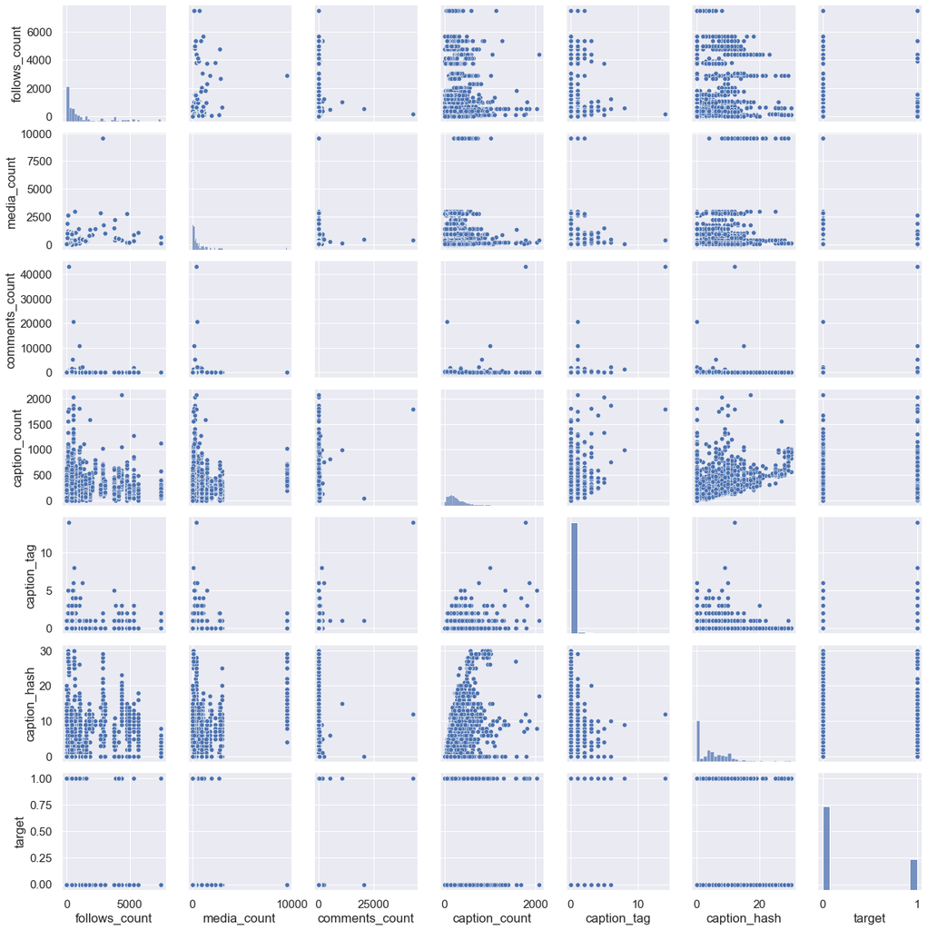

```python
import seaborn as sns
sns.pairplot(abt_model, diag_kind="hist")
```

```python
abt_model.shape
```

```
(2832, 14)
```

```python
# Definindo a divisão treino e teste

2832*0.7
```

```
1982.3999999999999
```

```python
# Check posts da mesma papelaria para fazer a divisão treino e teste

abt_model[1982:2004]
```

|  | link | account_name | is_business_account | business_category_name | follows_count | media_count | comments_count | type | weekday | time_range | caption_count | caption_tag | caption_hash | target |
| --- | --- | --- | --- | --- | --- | --- | --- | --- | --- | --- | --- | --- | --- | --- |
| 1985 | https://www.instagram.com/p/CF2VzewjAJ5 | papelariairmaos | yes | Home Services | 4962 | 207 | 2 | image | fri | manha | 35 | 0 | 2 | 0 |
| 1986 | https://www.instagram.com/p/CFzwCwwj76e | papelariairmaos | yes | Home Services | 4962 | 207 | 0 | image | thu | manha | 102 | 0 | 3 | 0 |
| 1987 | https://www.instagram.com/p/CFCop26jhRh | papelariairmaos | yes | Home Services | 4962 | 207 | 1 | image | sat | manha | 121 | 0 | 5 | 0 |
| 1988 | https://www.instagram.com/p/CE9xjIXjPaT | papelariairmaos | yes | Home Services | 4962 | 207 | 0 | image | thu | tarde | 84 | 0 | 3 | 0 |
| 1989 | https://www.instagram.com/p/CE6ynyjj-qx | papelariairmaos | yes | Home Services | 4962 | 207 | 0 | image | wed | manha | 143 | 0 | 2 | 0 |
| 1990 | https://www.instagram.com/p/CEwhYJSjgG5 | papelariairmaos | yes | Home Services | 4962 | 207 | 0 | image | sat | manha | 207 | 1 | 6 | 0 |
| 1991 | https://www.instagram.com/p/CEkcErVjqx0 | papelariairmaos | yes | Home Services | 4962 | 207 | 0 | image | mon | tarde | 83 | 0 | 2 | 0 |
| 1992 | https://www.instagram.com/p/CEZTQHcjyyu | papelariairmaos | yes | Home Services | 4962 | 207 | 0 | image | thu | manha | 302 | 0 | 4 | 0 |
| 1993 | https://www.instagram.com/p/CEMOLAAjQOb | papelariairmaos | yes | Home Services | 4962 | 207 | 0 | image | sat | manha | 60 | 0 | 2 | 0 |
| 1994 | https://www.instagram.com/p/CEHilBOjyne | papelariairmaos | yes | Home Services | 4962 | 207 | 2 | image | thu | manha | 260 | 0 | 7 | 0 |
| 1995 | https://www.instagram.com/p/CDzg01KDFr_ | papelariairmaos | yes | Home Services | 4962 | 207 | 2 | image | wed | tarde | 55 | 0 | 3 | 0 |
| 1996 | https://www.instagram.com/p/CCgdoH5jj2a | papelariairmaos | yes | Home Services | 4962 | 207 | 0 | image | sat | manha | 119 | 0 | 7 | 0 |
| 1997 | https://www.instagram.com/p/CCMeRWXjfI0 | papelariairmaos | yes | Home Services | 4962 | 207 | 6 | image | fri | tarde | 146 | 0 | 9 | 0 |
| 1998 | https://www.instagram.com/p/CCEuToOjXaE | papelariairmaos | yes | Home Services | 4962 | 207 | 0 | image | tue | tarde | 51 | 1 | 2 | 0 |
| 1999 | https://www.instagram.com/p/CB_4GYpDrDm | papelariairmaos | yes | Home Services | 4962 | 207 | 0 | image | sun | noite | 191 | 0 | 13 | 0 |
| 2000 | https://www.instagram.com/p/CB6hUA_jDlR | papelariairmaos | yes | Home Services | 4962 | 207 | 1 | image | fri | tarde | 137 | 0 | 12 | 0 |
| 2001 | https://www.instagram.com/p/CBqZc7gj755 | papelariairmaos | yes | Home Services | 4962 | 207 | 0 | image | sat | manha | 265 | 0 | 8 | 0 |
| 2002 | https://www.instagram.com/p/CBjKCILDJ6m | papelariairmaos | yes | Home Services | 4962 | 207 | 2 | image | wed | tarde | 286 | 1 | 11 | 0 |
| 2003 | https://www.instagram.com/p/CBeapIKDnCm | papelariairmaos | yes | Home Services | 4962 | 207 | 5 | image | mon | noite | 228 | 0 | 10 | 0 |
| 2004 | https://www.instagram.com/p/CA_N1T4jPnO | papelariairmaos | yes | Home Services | 4962 | 207 | 7 | image | wed | tarde | 170 | 0 | 14 | 0 |
| 2005 | https://www.instagram.com/p/CA8nPqdjM1R | papelariairmaos | yes | Home Services | 4962 | 207 | 0 | image | tue | tarde | 156 | 0 | 8 | 0 |
| 2006 | https://www.instagram.com/p/CSW6I4qLRoh | lovelypapelariavirtual | yes | Personal Goods & General Merchandise Stores | 2031 | 879 | 10 | sidecar | mon | manha | 307 | 0 | 7 | 0 |

#### Divisão da base em treino e teste deve ser feita considerando diferentes shops

```python
# Treino (˜ 70% da base) e teste

df_train = abt_model[0:2003] #2003 foi definido para contemplar posts de uma mesma papelaria
df_test = abt_model[2003:2833]
```

```python
df_train.shape, df_test.shape
```

```
((2003, 14), (829, 14))
```

```python
abt_model.dtypes
```

```
link                      object
account_name              object
is_business_account       object
business_category_name    object
follows_count              int64
media_count                int64
comments_count             int64
type                      object
weekday                   object
time_range                object
caption_count              int64
caption_tag                int64
caption_hash               int64
target                     int64
dtype: object
```

```python
# Identificação das variáveis

key_vars = ['link', 'account_name']
num_vars = ['follows_count', 'media_count', 'comments_count', 'caption_count', 'caption_tag', 'caption_hash']
cat_vars = ['type', 'weekday', 'time_range', 'is_business_account','business_category_name']
target = 'target'

features = num_vars + cat_vars
```

```python
import pycaret
pycaret.__version__
```

```
'2.3.3'
```

```python
# importando todas as funções do módulo classification da biblioteca pycaret
from pycaret.classification import *


exp_setup = setup(data=df_train, test_data=df_test, target='target',
                  ignore_features=key_vars, categorical_features=cat_vars, numeric_features=num_vars)
```

|  | Description | Value |
| --- | --- | --- |
| 0 | session_id | 2050 |
| 1 | Target | target |
| 2 | Target Type | Binary |
| 3 | Label Encoded | 0: 0, 1: 1 |
| 4 | Original Data | (2003, 14) |
| 5 | Missing Values | False |
| 6 | Numeric Features | 6 |
| 7 | Categorical Features | 5 |
| 8 | Ordinal Features | False |
| 9 | High Cardinality Features | False |
| 10 | High Cardinality Method | None |
| 11 | Transformed Train Set | (2003, 26) |
| 12 | Transformed Test Set | (829, 26) |
| 13 | Shuffle Train-Test | True |
| 14 | Stratify Train-Test | False |
| 15 | Fold Generator | StratifiedKFold |
| 16 | Fold Number | 10 |
| 17 | CPU Jobs | -1 |
| 18 | Use GPU | False |
| 19 | Log Experiment | False |
| 20 | Experiment Name | clf-default-name |
| 21 | USI | a1b0 |
| 22 | Imputation Type | simple |
| 23 | Iterative Imputation Iteration | None |
| 24 | Numeric Imputer | mean |
| 25 | Iterative Imputation Numeric Model | None |
| 26 | Categorical Imputer | constant |
| 27 | Iterative Imputation Categorical Model | None |
| 28 | Unknown Categoricals Handling | least_frequent |
| 29 | Normalize | False |
| 30 | Normalize Method | None |
| 31 | Transformation | False |
| 32 | Transformation Method | None |
| 33 | PCA | False |
| 34 | PCA Method | None |
| 35 | PCA Components | None |
| 36 | Ignore Low Variance | False |
| 37 | Combine Rare Levels | False |
| 38 | Rare Level Threshold | None |
| 39 | Numeric Binning | False |
| 40 | Remove Outliers | False |
| 41 | Outliers Threshold | None |
| 42 | Remove Multicollinearity | False |
| 43 | Multicollinearity Threshold | None |
| 44 | Remove Perfect Collinearity | True |
| 45 | Clustering | False |
| 46 | Clustering Iteration | None |
| 47 | Polynomial Features | False |
| 48 | Polynomial Degree | None |
| 49 | Trignometry Features | False |
| 50 | Polynomial Threshold | None |
| 51 | Group Features | False |
| 52 | Feature Selection | False |
| 53 | Feature Selection Method | classic |
| 54 | Features Selection Threshold | None |
| 55 | Feature Interaction | False |
| 56 | Feature Ratio | False |
| 57 | Interaction Threshold | None |
| 58 | Fix Imbalance | False |
| 59 | Fix Imbalance Method | SMOTE |

```python
type(exp_setup)
```

```
tuple
```

```python
len(exp_setup)
```

```
42
```

```python
help(get_config)
```

```
Help on function get_config in module pycaret.classification:

get_config(variable: str)
    This function retrieves the global variables created when initializing the
    ``setup`` function. Following variables are accessible:

    - X: Transformed dataset (X)
    - y: Transformed dataset (y)
    - X_train: Transformed train dataset (X)
    - X_test: Transformed test/holdout dataset (X)
    - y_train: Transformed train dataset (y)
    - y_test: Transformed test/holdout dataset (y)
    - seed: random state set through session_id
    - prep_pipe: Transformation pipeline
    - fold_shuffle_param: shuffle parameter used in Kfolds
    - n_jobs_param: n_jobs parameter used in model training
    - html_param: html_param configured through setup
    - create_model_container: results grid storage container
    - master_model_container: model storage container
    - display_container: results display container
    - exp_name_log: Name of experiment
    - logging_param: log_experiment param
    - log_plots_param: log_plots param
    - USI: Unique session ID parameter
    - fix_imbalance_param: fix_imbalance param
    - fix_imbalance_method_param: fix_imbalance_method param
    - data_before_preprocess: data before preprocessing
    - target_param: name of target variable
    - gpu_param: use_gpu param configured through setup
    - fold_generator: CV splitter configured in fold_strategy
    - fold_param: fold params defined in the setup
    - fold_groups_param: fold groups defined in the setup
    - stratify_param: stratify parameter defined in the setup


    Example
    -------
    >>> from pycaret.datasets import get_data
    >>> juice = get_data('juice')
    >>> from pycaret.classification import *
    >>> exp_name = setup(data = juice,  target = 'Purchase')
    >>> X_train = get_config('X_train')


    Returns:
        Global variable
```

```python
get_config('X')
```

|  | follows_count | media_count | comments_count | caption_count | caption_tag | caption_hash | is_business_account_yes | business_category_name_Creators & Celebrities | business_category_name_Food & Personal Goods | business_category_name_General Interest | ... | weekday_mon | weekday_sat | weekday_sun | weekday_thu | weekday_tue | weekday_wed | time_range_madrugada | time_range_manha | time_range_noite | time_range_tarde |
| --- | --- | --- | --- | --- | --- | --- | --- | --- | --- | --- | --- | --- | --- | --- | --- | --- | --- | --- | --- | --- | --- |
| 0 | 617.0 | 2977.0 | 2.0 | 91.0 | 0.0 | 0.0 | 0.0 | 0.0 | 0.0 | 0.0 | ... | 0.0 | 0.0 | 0.0 | 0.0 | 0.0 | 0.0 | 0.0 | 1.0 | 0.0 | 0.0 |
| 1 | 617.0 | 2977.0 | 3.0 | 201.0 | 0.0 | 6.0 | 0.0 | 0.0 | 0.0 | 0.0 | ... | 0.0 | 0.0 | 0.0 | 0.0 | 0.0 | 0.0 | 1.0 | 0.0 | 0.0 | 0.0 |
| 2 | 617.0 | 2977.0 | 7.0 | 144.0 | 0.0 | 5.0 | 0.0 | 0.0 | 0.0 | 0.0 | ... | 0.0 | 0.0 | 0.0 | 1.0 | 0.0 | 0.0 | 0.0 | 0.0 | 1.0 | 0.0 |
| 3 | 617.0 | 2977.0 | 4.0 | 176.0 | 0.0 | 6.0 | 0.0 | 0.0 | 0.0 | 0.0 | ... | 0.0 | 0.0 | 0.0 | 1.0 | 0.0 | 0.0 | 0.0 | 0.0 | 0.0 | 1.0 |
| 4 | 617.0 | 2977.0 | 10.0 | 375.0 | 0.0 | 20.0 | 0.0 | 0.0 | 0.0 | 0.0 | ... | 0.0 | 0.0 | 0.0 | 0.0 | 0.0 | 1.0 | 0.0 | 0.0 | 0.0 | 1.0 |
| ... | ... | ... | ... | ... | ... | ... | ... | ... | ... | ... | ... | ... | ... | ... | ... | ... | ... | ... | ... | ... | ... |
| 2001 | 4962.0 | 207.0 | 0.0 | 265.0 | 0.0 | 8.0 | 1.0 | 0.0 | 0.0 | 0.0 | ... | 0.0 | 1.0 | 0.0 | 0.0 | 0.0 | 0.0 | 0.0 | 1.0 | 0.0 | 0.0 |
| 2002 | 4962.0 | 207.0 | 2.0 | 286.0 | 1.0 | 11.0 | 1.0 | 0.0 | 0.0 | 0.0 | ... | 0.0 | 0.0 | 0.0 | 0.0 | 0.0 | 1.0 | 0.0 | 0.0 | 0.0 | 1.0 |
| 2003 | 4962.0 | 207.0 | 5.0 | 228.0 | 0.0 | 10.0 | 1.0 | 0.0 | 0.0 | 0.0 | ... | 1.0 | 0.0 | 0.0 | 0.0 | 0.0 | 0.0 | 0.0 | 0.0 | 1.0 | 0.0 |
| 2004 | 4962.0 | 207.0 | 7.0 | 170.0 | 0.0 | 14.0 | 1.0 | 0.0 | 0.0 | 0.0 | ... | 0.0 | 0.0 | 0.0 | 0.0 | 0.0 | 1.0 | 0.0 | 0.0 | 0.0 | 1.0 |
| 2005 | 4962.0 | 207.0 | 0.0 | 156.0 | 0.0 | 8.0 | 1.0 | 0.0 | 0.0 | 0.0 | ... | 0.0 | 0.0 | 0.0 | 0.0 | 1.0 | 0.0 | 0.0 | 0.0 | 0.0 | 1.0 |

2003 rows × 26 columns

```python
get_config(variable="X_test")
```

|  | follows_count | media_count | comments_count | caption_count | caption_tag | caption_hash | is_business_account_yes | business_category_name_Creators & Celebrities | business_category_name_Food & Personal Goods | business_category_name_General Interest | ... | weekday_mon | weekday_sat | weekday_sun | weekday_thu | weekday_tue | weekday_wed | time_range_madrugada | time_range_manha | time_range_noite | time_range_tarde |
| --- | --- | --- | --- | --- | --- | --- | --- | --- | --- | --- | --- | --- | --- | --- | --- | --- | --- | --- | --- | --- | --- |
| 2006 | 2031.0 | 879.0 | 10.0 | 307.0 | 0.0 | 7.0 | 1.0 | 0.0 | 0.0 | 0.0 | ... | 1.0 | 0.0 | 0.0 | 0.0 | 0.0 | 0.0 | 0.0 | 1.0 | 0.0 | 0.0 |
| 2007 | 2031.0 | 879.0 | 16.0 | 249.0 | 0.0 | 7.0 | 1.0 | 0.0 | 0.0 | 0.0 | ... | 0.0 | 1.0 | 0.0 | 0.0 | 0.0 | 0.0 | 0.0 | 1.0 | 0.0 | 0.0 |
| 2008 | 2031.0 | 879.0 | 29.0 | 446.0 | 0.0 | 9.0 | 1.0 | 0.0 | 0.0 | 0.0 | ... | 0.0 | 0.0 | 0.0 | 0.0 | 0.0 | 0.0 | 0.0 | 1.0 | 0.0 | 0.0 |
| 2009 | 2031.0 | 879.0 | 4.0 | 327.0 | 0.0 | 8.0 | 1.0 | 0.0 | 0.0 | 0.0 | ... | 0.0 | 0.0 | 0.0 | 1.0 | 0.0 | 0.0 | 0.0 | 1.0 | 0.0 | 0.0 |
| 2010 | 2031.0 | 879.0 | 6.0 | 330.0 | 0.0 | 9.0 | 1.0 | 0.0 | 0.0 | 0.0 | ... | 0.0 | 0.0 | 0.0 | 0.0 | 0.0 | 1.0 | 0.0 | 1.0 | 0.0 | 0.0 |
| ... | ... | ... | ... | ... | ... | ... | ... | ... | ... | ... | ... | ... | ... | ... | ... | ... | ... | ... | ... | ... | ... |
| 2830 | 2280.0 | 1431.0 | 0.0 | 652.0 | 0.0 | 10.0 | 1.0 | 0.0 | 0.0 | 0.0 | ... | 0.0 | 0.0 | 0.0 | 0.0 | 0.0 | 1.0 | 0.0 | 1.0 | 0.0 | 0.0 |
| 2831 | 2280.0 | 1431.0 | 7.0 | 565.0 | 0.0 | 10.0 | 1.0 | 0.0 | 0.0 | 0.0 | ... | 0.0 | 0.0 | 0.0 | 0.0 | 1.0 | 0.0 | 0.0 | 0.0 | 0.0 | 1.0 |
| 2832 | 2280.0 | 1431.0 | 2.0 | 621.0 | 0.0 | 10.0 | 1.0 | 0.0 | 0.0 | 0.0 | ... | 0.0 | 0.0 | 0.0 | 0.0 | 1.0 | 0.0 | 0.0 | 0.0 | 0.0 | 1.0 |
| 2833 | 2280.0 | 1431.0 | 12.0 | 550.0 | 0.0 | 10.0 | 1.0 | 0.0 | 0.0 | 0.0 | ... | 1.0 | 0.0 | 0.0 | 0.0 | 0.0 | 0.0 | 0.0 | 0.0 | 0.0 | 1.0 |
| 2834 | 2280.0 | 1431.0 | 6.0 | 800.0 | 0.0 | 10.0 | 1.0 | 0.0 | 0.0 | 0.0 | ... | 1.0 | 0.0 | 0.0 | 0.0 | 0.0 | 0.0 | 0.0 | 0.0 | 0.0 | 1.0 |

829 rows × 26 columns

```python
df_train.head()
```

|  | link | account_name | is_business_account | business_category_name | follows_count | media_count | comments_count | type | weekday | time_range | caption_count | caption_tag | caption_hash | target |
| --- | --- | --- | --- | --- | --- | --- | --- | --- | --- | --- | --- | --- | --- | --- |
| 0 | https://www.instagram.com/p/CShD4lTLE2C | papelarialiane | no | not defined | 617 | 2977 | 2 | image | fri | manha | 91 | 0 | 0 | 0 |
| 1 | https://www.instagram.com/p/CSgsvz_rV1B | papelarialiane | no | not defined | 617 | 2977 | 3 | image | fri | madrugada | 201 | 0 | 6 | 0 |
| 2 | https://www.instagram.com/p/CSfjFF1H7zV | papelarialiane | no | not defined | 617 | 2977 | 7 | video | thu | noite | 144 | 0 | 5 | 0 |
| 3 | https://www.instagram.com/p/CSfP3jtrbLQ | papelarialiane | no | not defined | 617 | 2977 | 4 | sidecar | thu | tarde | 176 | 0 | 6 | 0 |
| 4 | https://www.instagram.com/p/CScyNG7H_FX | papelarialiane | no | not defined | 617 | 2977 | 10 | video | wed | tarde | 375 | 0 | 20 | 0 |

```python
get_config('prep_pipe')
```

```
Pipeline(memory=None,
         steps=[('dtypes',
                 DataTypes_Auto_infer(categorical_features=['type', 'weekday',
                                                            'time_range',
                                                            'is_business_account',
                                                            'business_category_name'],
                                      display_types=True,
                                      features_todrop=['link', 'account_name'],
                                      id_columns=[],
                                      ml_usecase='classification',
                                      numerical_features=['follows_count',
                                                          'media_count',
                                                          'comments_count',
                                                          'caption_count',
                                                          'captio...
                ('scaling', 'passthrough'), ('P_transform', 'passthrough'),
                ('binn', 'passthrough'), ('rem_outliers', 'passthrough'),
                ('cluster_all', 'passthrough'),
                ('dummy', Dummify(target='target')),
                ('fix_perfect', Remove_100(target='target')),
                ('clean_names', Clean_Colum_Names()),
                ('feature_select', 'passthrough'), ('fix_multi', 'passthrough'),
                ('dfs', 'passthrough'), ('pca', 'passthrough')],
         verbose=False)
```

```python
compare_models(fold=5, sort='auc')
```

|  | Model | Accuracy | AUC | Recall | Prec. | F1 | Kappa | MCC | TT (Sec) |
| --- | --- | --- | --- | --- | --- | --- | --- | --- | --- |
| lr | Logistic Regression | 0.7513 | 0.8132 | 0.4606 | 0.5967 | 0.4828 | 0.3304 | 0.3542 | 1.6300 |
| catboost | CatBoost Classifier | 0.6923 | 0.7785 | 0.4847 | 0.5255 | 0.4430 | 0.2507 | 0.2871 | 1.5880 |
| gbc | Gradient Boosting Classifier | 0.6824 | 0.7756 | 0.5143 | 0.5056 | 0.4537 | 0.2503 | 0.2823 | 0.2040 |
| lightgbm | Light Gradient Boosting Machine | 0.6753 | 0.7546 | 0.4940 | 0.5238 | 0.4359 | 0.2321 | 0.2730 | 0.7040 |
| xgboost | Extreme Gradient Boosting | 0.6723 | 0.7538 | 0.5049 | 0.5142 | 0.4448 | 0.2346 | 0.2718 | 0.5680 |
| lda | Linear Discriminant Analysis | 0.7318 | 0.7471 | 0.3146 | 0.5749 | 0.3699 | 0.2226 | 0.2564 | 0.0380 |
| rf | Random Forest Classifier | 0.7108 | 0.7413 | 0.4939 | 0.5277 | 0.4685 | 0.2835 | 0.3085 | 0.3180 |
| ada | Ada Boost Classifier | 0.6874 | 0.7225 | 0.5087 | 0.5098 | 0.4487 | 0.2505 | 0.2844 | 0.1180 |
| nb | Naive Bayes | 0.6520 | 0.7149 | 0.6794 | 0.4324 | 0.4933 | 0.2607 | 0.3099 | 0.0220 |
| et | Extra Trees Classifier | 0.7114 | 0.7123 | 0.4275 | 0.4930 | 0.4335 | 0.2500 | 0.2625 | 0.2700 |
| knn | K Neighbors Classifier | 0.6459 | 0.6528 | 0.5049 | 0.4301 | 0.4283 | 0.1932 | 0.2113 | 0.0540 |
| dt | Decision Tree Classifier | 0.6349 | 0.5982 | 0.5176 | 0.4335 | 0.4448 | 0.1972 | 0.2061 | 0.0200 |
| qda | Quadratic Discriminant Analysis | 0.5441 | 0.4824 | 0.3477 | 0.2557 | 0.2637 | -0.0222 | -0.0359 | 0.0260 |
| svm | SVM - Linear Kernel | 0.7229 | 0.0000 | 0.4365 | 0.5693 | 0.4357 | 0.2663 | 0.2952 | 0.0200 |
| ridge | Ridge Classifier | 0.7244 | 0.0000 | 0.2502 | 0.5539 | 0.3058 | 0.1701 | 0.2076 | 0.0260 |

```
LogisticRegression(C=1.0, class_weight=None, dual=False, fit_intercept=True,
                   intercept_scaling=1, l1_ratio=None, max_iter=1000,
                   multi_class='auto', n_jobs=None, penalty='l2',
                   random_state=2050, solver='lbfgs', tol=0.0001, verbose=0,
                   warm_start=False)
```

```python
model = create_model('lr', fold=5)
```

|  | Accuracy | AUC | Recall | Prec. | F1 | Kappa | MCC |
| --- | --- | --- | --- | --- | --- | --- | --- |
| 0 | 0.8030 | 0.8491 | 0.4220 | 0.7419 | 0.5380 | 0.4246 | 0.4519 |
| 1 | 0.7781 | 0.8276 | 0.6606 | 0.5806 | 0.6180 | 0.4625 | 0.4644 |
| 2 | 0.7706 | 0.8004 | 0.2110 | 0.7931 | 0.3333 | 0.2473 | 0.3271 |
| 3 | 0.6500 | 0.7859 | 0.2963 | 0.3333 | 0.3137 | 0.0799 | 0.0802 |
| 4 | 0.7550 | 0.8031 | 0.7130 | 0.5347 | 0.6111 | 0.4376 | 0.4472 |
| Mean | 0.7513 | 0.8132 | 0.4606 | 0.5967 | 0.4828 | 0.3304 | 0.3542 |
| SD | 0.0530 | 0.0224 | 0.1972 | 0.1632 | 0.1332 | 0.1466 | 0.1457 |

```python
model
```

```
LogisticRegression(C=1.0, class_weight=None, dual=False, fit_intercept=True,
                   intercept_scaling=1, l1_ratio=None, max_iter=1000,
                   multi_class='auto', n_jobs=None, penalty='l2',
                   random_state=2050, solver='lbfgs', tol=0.0001, verbose=0,
                   warm_start=False)
```

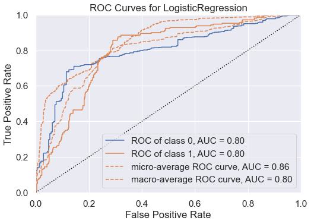

```python
plot_model(model, plot='auc')
```

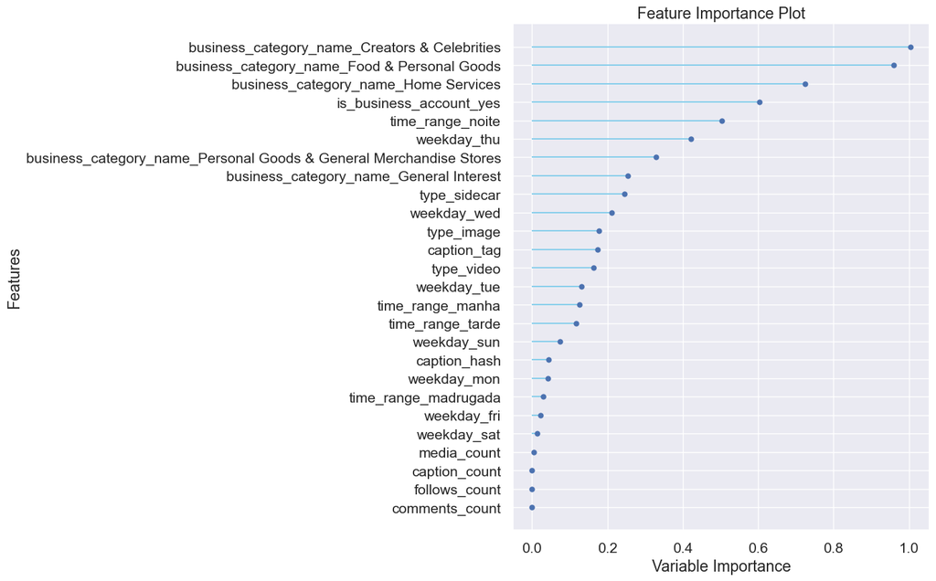

```python
plot_model(model, plot='feature_all')
```

```python
plot_model(model, plot='parameter')
```

|  | Parameters |
| --- | --- |
| C | 1.0 |
| class_weight | None |
| dual | False |
| fit_intercept | True |
| intercept_scaling | 1 |
| l1_ratio | None |
| max_iter | 1000 |
| multi_class | auto |
| n_jobs | None |
| penalty | l2 |
| random_state | 2050 |
| solver | lbfgs |
| tol | 0.0001 |
| verbose | 0 |
| warm_start | False |

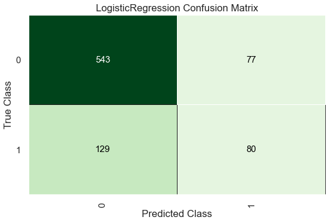

```python
# Nos dados de teste
plot_model(model, plot='confusion_matrix')
```